# RHESSysIOinR_Coweeta_WS32_74 Multi Site Validation Field Data_Step4

Carlos Quintero

6/17/2024

Coweeta Hydrologic Laboratory Watershed 32 using Static, SSURGO, and RSS soil inputs.

The following R Markdown script prepares and runs the Regional Hydro-Ecologic Simulation System (RHESSYS) within the R environment. Modified from RHESSysIOinR example scripts created by Will Burke and Ryan Bart. Includes CLHS code snippets and SDA code from Dylan Beaudette.

Windows Subsystem via Linux must be installed before RHESSys will run in a Windows environment. GRASS8 must be installed to run the spatial preprocessing portion of the script.

Code has been modified to run RHESSys 7.4 and 5.18. 7.4 vegetation processing differs slightly from 5.18. Various template differences exist between the two versions of RHESSys and template files must be carefully reviewed if moving between versions. This script is currently set up to run RHESSys 7.4

```r
knitr::opts_chunk$set(warning = FALSE, message = FALSE)
#install.packages("devtools")
#devtools::install_github("ropensci/FedData")

library(aqp)
library(daymetr)
library(clhs)
library(EcoHydRology)
```

```r
library(elevatr)
library(ezknitr)
#library(FedData)
library(foreach)
library(foreign)
library(ggplot2)
library(ggpubr)
library(hydroGOF)
library(imputeTS)
library(knitr)
library(latticeExtra)
library(lubridate)
library(Metrics)
library(raster)
library(rasterVis)
library(readxl)
library(reshape2)
library(rgdal)
library(rgrass)
library(rmarkdown)
library(Rmisc)
library(RHESSysPreprocessing)
library(RHESSysIOinR)
library(sf)
library(soilDB)
library(sp)
library(stats)
library(stringi)
library(tactile)
library(terra)
library(testthat)
library(tidyverse)
library(viridisLite)
library(dplyr)

setwd(system.file("extdata/", package = "RHESSysIOinR"))
getwd()
```

```
## [1] "C:/Users/Carlos/Documents/R/win-library/4.0/RHESSysIOinR/extdata"
```

```r
rh_ver = dir(path = "modelfiles/rhessys/", pattern = "^rhessys\\d+",recursive = F)
rh_path = file.path("modelfiles/rhessys", rh_ver)

## Load in necessary files
filedir <- ("C:/Users/Carlos/Documents/GitHub/RHESSys74-R-Markdown/")

watershedshapefile <- paste0(filedir, "input_files/shapefiles/watersheds/Coweeta_Hydrologic_Laboratory.shp")
streamshapefile<- paste0(filedir,"input_files/shapefiles/streams/StreamsCaldwellClipped.shp")
weirshapefile<- paste0(filedir,"input_files/shapefiles/weirs/Subbasinoutlets.shp")
roadshapefile <- paste0(filedir, "input_files/shapefiles/roads/UpdatedRoads4Reprojected32617.shp")

CWRG12 <- paste0(filedir,"input_files/precipitation/RDS-2017-0031/Data/RG12_daily_1942_2021.csv")
CWRG20 <-paste0(filedir,"input_files/precipitation/RDS-2017-0031/Data/RG20_daily_1962_2021.csv")

CS21<- paste0(filedir,"input_files/temperature/RDS-2015-0042/Data/cs21_daily.csv")
CS28<- paste0(filedir,"input_files/temperature/RDS-2015-0042/Data/cs28_daily.csv")

newsmlocations<-  paste0(filedir,"input_files/shapefiles/soil_moisture/CoweetaNRCSsmKML.kml")
```

New Patch Filter

Basin - Basin Hillslope - Subbasin Zone - Patch Patch - Patch

1 112 136557 1 110 141942 1 110 149478

## note that streamflow output from patch filter is in mm

```r
setwd(system.file("extdata/", package = "RHESSysIOinR"))

patchfilterpatch1 = build_output_filter(timestep = "daily",
                                   output_format = "csv",
                                   output_path = "outputfilter",
                                   output_filename = "ws32patch1",
                                   spatial_level = "patch",
                                   spatial_ID = "1:69:144625:144625",
                                   variables = c("rootzone.S","rootzone.potential_sat","rootzone.field_capacity", "rz_storage"))

patchfilterpatch2 = build_output_filter(timestep = "daily",
                                   output_format = "csv",
                                   output_path = "outputfilter",
                                   output_filename = "ws32patch2",
                                   spatial_level = "patch",
                                   spatial_ID = "1:69:149472:149472",
                                   variables = c("rootzone.S","rootzone.potential_sat","rootzone.field_capacity", "rz_storage"))

patchfilterpatch3 = build_output_filter(timestep = "daily",
                                   output_format = "csv",
                                   output_path = "outputfilter",
                                   output_filename = "ws32patch3",
                                   spatial_level = "patch",
                                   spatial_ID = "1:69:157007:157007",
                                   variables = c("rootzone.S","rootzone.potential_sat","rootzone.field_capacity", "rz_storage"))


basinfilter_static = build_output_filter(timestep = "daily",
                                   output_format = "csv",
                                   output_path = "outputfilter",
                                   output_filename = "static_basin_daily",
                                   spatial_level = "basin",
                                   spatial_ID = as.integer("1"),
                                   variables = c("hill.gw.Qout","patch.rootzone.S","patch.rootzone.potential_sat","patch.rootzone.field_capacity", "patch.rz_storage","patch.total_water_in", "patch.streamflow", "patch.evaporation" ))


basinfilter_ssurgo = build_output_filter(timestep = "daily",
                                   output_format = "csv",
                                   output_path = "outputfilter",
                                   output_filename = "ssurgo_basin_daily",
                                   spatial_level = "basin",
                                   spatial_ID = as.integer("1"),
                                   variables = c("hill.gw.Qout","patch.rootzone.S","patch.rootzone.potential_sat","patch.rootzone.field_capacity", "patch.rz_storage","patch.total_water_in", "patch.streamflow", "patch.evaporation" ))


basinfilter_dsm = build_output_filter(timestep = "daily",
                                   output_format = "csv",
                                   output_path = "outputfilter",
                                   output_filename = "dsm_basin_daily",
                                   spatial_level = "basin",
                                   spatial_ID = as.integer("1"),
                                   variables = c("hill.gw.Qout","patch.rootzone.S","patch.rootzone.potential_sat","patch.rootzone.field_capacity", "patch.rz_storage","patch.total_water_in", "patch.streamflow", "patch.evaporation" ))

# start_time = Sys.time()
# start_time
# run_rhessys_single(input_rhessys = input_rhessys,
#                    hdr_files = input_hdr,
#                    tec_data = input_tec_data,
#                    cmd_pars = stdpars,
#                    output_filter = c(patchfilterpatch1,patchfilterpatch2,patchfilterpatch3),
#                    runID = 'single')
# end_time = Sys.time()
# end_time - start_time
# end_time
```

Setup RHESSys Calibration, CLHS used to reduce amount of samples processed

The model calibrates over the following parameters.

M - Decay of hydraulic conductivity with depth K - Hydraulic conductivity at the surface Sd - soil depth Mv - Vertical decay of hydraulic conductivity with depth Kv - Vertical hydraulic conductivity at the surface GW1 - Saturated to Groundwater Coefficient GW2 - Groundwater Loss Coefficient

Parameter & Typical Range from RHESSys Wiki

M - .01 - 20 K - 1 - 600 GW1 - .001 - .3 GW2 - .01 - .9

" In order to generate an adequate sample across the full range for each parameter, values from .001 - .01, values from .01 - 1, and values over 1 should be generated separately. The m and K parameters are multipliers on the initial values set for m and K (values assigned to the m and K maps)." - Taken from RHESSys Wiki

Additional Calibration Parameters are available natively although they are not as well documented

pa - multiplier to scale the pore size index po - multiplier to scale the psi air entry

vseng1 - multiplies specific leaf areas vseng2 - multiplies the ratio of shaded to sunlit leaf area vseng3 - Multiplier used only with the Dickenson algorithm of carbon allocation (set with the epc.allocation_flag variable in the vegetation definition file). It changes the allocation of net photosynthate sensitivity based on the current LAI. If not using the Dickenson strategy of carbon allocation (i.e. using Waring or default Constant strategies), set third value to 1.0. (i.e. -vgsen 1.0 2.0 1.0)

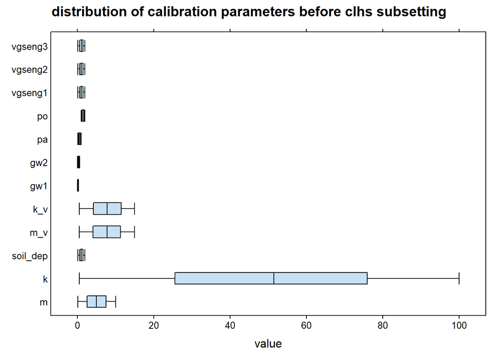

```r
setwd(system.file("extdata/", package = "RHESSysIOinR"))
# number of samples for full data space
fs <- 10000
# number of samples to calibrate over, 100 samples take approx 40 mins in base R and 1 hour in rmarkdown
n <- 100
# create data frame
d <- data.frame(
  m = runif(fs, min=0.1, max=10),
  k = runif(fs, min=0.5, max=100),
  soil_dep = runif(fs, min=0.1, max=2),
  m_v = runif(fs, min=0.5, max=15),
  k_v = runif(fs, min=0.5, max=15),
  gw1 = runif(fs, min=0.01, max=0.3),
  gw2 = runif(fs, min=0.01, max=0.6),
  pa = runif(fs, min=0.1, max=1.0),
  po = runif(fs, min=1.0, max=2.0),
  vgseng1 = runif(fs, min=0.1, max=2.0),
  vgseng2 = runif(fs, min=0.1, max=2.0),
  vgseng3 = runif(fs, min=0.1, max=2.0))
# marginal distributions, for analysis
m <- melt(d)
bwplot(variable ~ value, data = m, par.settings = tactile.theme(), main = "distribution of calibration parameters before clhs subsetting")
```

```r
# cLHS subset
s <- clhs(d, size = n, simple = TRUE, use.cpp = TRUE)
# combine full dataset + subset
g <- make.groups(full = d, cLHS = d[s, ])
# create new list
params<- d[s, ]

params[1:5,]
```

```
##             m        k  soil_dep       m_v       k_v        gw1       gw2
## 2433 9.285003 98.47550 1.5020565  3.163408  4.305650 0.03511527 0.3239591
## 6232 1.297459 68.94711 1.8275500 11.243880  2.830821 0.07826344 0.1054040
## 7601 8.508998 44.44225 0.2634427 12.288184  9.656335 0.16935457 0.5293000
## 8641 5.879520 20.70778 0.6108011 10.401852 13.353385 0.23907140 0.3900851
## 7796 7.913364 60.95755 1.4873389  9.464417 11.994103 0.20173739 0.3005929
##             pa       po   vgseng1   vgseng2   vgseng3
## 2433 0.9137139 1.309053 0.8172864 1.7433233 1.8378933
## 6232 0.4059166 1.460581 1.6961387 1.1747605 0.9656007
## 7601 0.9376218 1.175165 1.1012005 0.6253698 1.6945747
## 8641 0.7768686 1.779977 0.5784418 0.7557042 0.4808007
## 7796 0.7366021 1.013335 0.7854628 0.7933709 1.2347702
```

```r
## Quick and dirty way to include "uncalibrated" result to test against, groundwater model still included for now, unsure of what to do with parameters for gw
## params[1,] = c(1,1,1,1,1,0,0)
## did not produce significantly different result

#write param table to specific text file if file does not exist
## if name is not changed then old table is used
# paramtablename = "out/cwparamtable.txt"

getwd()
```

```
## [1] "C:/Users/Carlos/Documents/R/win-library/4.0/RHESSysIOinR/extdata"
```

```r
##UNCOMMENT TO WRITE NEW PARAMS
#  write.table(params, file = "out/cwparamtable.txt")
###

### writes new params table with todays date to a text file
#write.table(params, file = paste("out/cwparamtable",format(Sys.Date(),"%m%d%y"),".txt",sep = ""))

## reads in specific params file, used for keeping input params constant for analysis
## do not rewrite file if it exits

#{if (file.exists("out/cwparamtable.txt"))
#   print("text")}

params <- read.table(file = "out/cwparamtable.txt")

# prepare RHESSys for run
params<- as.data.frame(params)

input_rhessys = IOin_rhessys_input(
  version = rh_path,
  tec_file = "tecfiles/tec_daily",
  world_file = "CWWS32dsm.world.Y2018M11D1H1.state.Y2018M11D1H1.state",
  world_hdr_prefix = "CWWS32dsm",
  flowtable = "CWWS32dsm.flow",
  start = "2013 11 1 1",
  end = "2018 11 1 1",
  output_folder = "out",
  output_prefix = "cwws32",
  commandline_options = c("-b"))

#commandline_options = c("-b -p 1 128 154914 154914 ")) <- Patch Specific Output

input_tec_data = IOin_tec_std(start = "2015 11 1 1",
                              end = "2018 11 1 1",
                              output_state = FALSE)

soildefs <- list.files("defs/", pattern = "soil_", full.names = TRUE)

input_hdr = IOin_hdr(
  basin = "defs/basin.def",
  hillslope = "defs/hillslope.def",
  zone = "defs/zone.def",
  soil = soildefs,
  landuse = c("defs/lu_undev.def","defs/lu_agriculture.def","defs/lu_raingarden.def","defs/lu_urban.def"),
  stratum = c("defs/veg_deciduous/veg_deciduous.def","defs/veg_evergreen/veg_evergreen.def","defs/veg_deciduous_BES.def","defs/veg_eucalypt.def","defs/veg_grass.def","defs/veg_lawn_2cm.def","defs/veg_lawn_5cm.def","defs/veg_lawn_10cm.def","defs/veg_nonveg.def"),
  basestations = "clim/cwtws32local.base")
```

Run RHESSys n times sequentially

# NO LONGER USED

Run RHESSys in Parallel using the foreach package, leaving 4 cores available for other tasks

# Modify for MCMC

## must refine calibration to do multiple steps, first gw1 gw2, then other variables

## multi point calibration and validation

Prepare Static, SSURGO, and DSM Inputs

```r
setwd(system.file("extdata/", package = "RHESSysIOinR"))
# prepare RHESSys for run


params <- read.table(file = "out/cwparamtable.txt")

params<- as.data.frame(params)

n <- nrow(params)

soildefs <- list.files("defs/", pattern = "soil_", full.names = TRUE)

input_rhessys_static = IOin_rhessys_input(
  version = rh_path,
  tec_file = "tecfiles/tec_daily",
  world_file = "CWWS32static.world.Y2018M11D1H1.state.Y2018M11D1H1.state",
  world_hdr_prefix = "CWWS32static",
  flowtable = "CWWS32static.flow",
  start = "2013 11 1 1",
  end = "2018 11 1 1",
  output_folder = "out",
  output_prefix = "cwws32static",
  commandline_options = c())

input_tec_data = IOin_tec_std(start = "2015 11 1 1",
                              end = "2018 11 1 1",
                              output_state = FALSE)

input_hdr_static = IOin_hdr(
  basin = "defs/basin.def",
  hillslope = "defs/hillslope.def",
  zone = "defs/zone.def",
  soil = soildefs,
  landuse = c("defs/lu_undev.def","defs/lu_agriculture.def","defs/lu_raingarden.def","defs/lu_urban.def"),
  stratum = c("defs/veg_deciduous/veg_deciduous.def","defs/veg_evergreen/veg_evergreen.def","defs/veg_deciduous_BES.def","defs/veg_eucalypt.def","defs/veg_grass.def","defs/veg_lawn_2cm.def","defs/veg_lawn_5cm.def","defs/veg_lawn_10cm.def","defs/veg_nonveg.def"),
  basestations = "clim/cwtws32local.base")


input_rhessys_ssurgo = IOin_rhessys_input(
  version = rh_path,
  tec_file = "tecfiles/tec_daily",
  world_file = "CWWS32ssurgo.world.Y2018M11D1H1.state.Y2018M11D1H1.state",
  world_hdr_prefix = "CWWS32ssurgo",
  flowtable = "CWWS32ssurgo.flow",
  start = "2013 11 1 1",
  end = "2018 11 1 1",
  output_folder = "out",
  output_prefix = "cwws32ssurgo",
  commandline_options = c())

input_hdr_ssurgo = IOin_hdr(
  basin = "defs/basin.def",
  hillslope = "defs/hillslope.def",
  zone = "defs/zone.def",
  soil = soildefs,
  landuse = c("defs/lu_undev.def","defs/lu_agriculture.def","defs/lu_raingarden.def","defs/lu_urban.def"),
  stratum = c("defs/veg_deciduous/veg_deciduous.def","defs/veg_evergreen/veg_evergreen.def","defs/veg_deciduous_BES.def","defs/veg_eucalypt.def","defs/veg_grass.def","defs/veg_lawn_2cm.def","defs/veg_lawn_5cm.def","defs/veg_lawn_10cm.def","defs/veg_nonveg.def"),
  basestations = "clim/cwtws32local.base")


input_rhessys_dsm = IOin_rhessys_input(
  version = rh_path,
  tec_file = "tecfiles/tec_daily",
  world_file = "CWWS32dsm.world.Y2018M11D1H1.state.Y2018M11D1H1.state",
  world_hdr_prefix = "CWWS32dsm",
  flowtable = "CWWS32dsm.flow",
  start = "2013 11 1 1",
  end = "2018 11 1 1",
  output_folder = "out",
  output_prefix = "cwws32dsm",
  commandline_options = c())

input_hdr_dsm = IOin_hdr(
  basin = "defs/basin.def",
  hillslope = "defs/hillslope.def",
  zone = "defs/zone.def",
  soil = soildefs,
  landuse = c("defs/lu_undev.def","defs/lu_agriculture.def","defs/lu_raingarden.def","defs/lu_urban.def"),
  stratum = c("defs/veg_deciduous/veg_deciduous.def","defs/veg_evergreen/veg_evergreen.def","defs/veg_deciduous_BES.def","defs/veg_eucalypt.def","defs/veg_grass.def","defs/veg_lawn_2cm.def","defs/veg_lawn_5cm.def","defs/veg_lawn_10cm.def","defs/veg_nonveg.def"),
  basestations = "clim/cwtws32local.base")
```

Run RHESSys Calibration with Static Maps

```r
setwd(system.file("extdata/", package = "RHESSysIOinR"))
n.cores <- parallel::detectCores() - 4

my.cluster <- parallel::makeCluster(
    n.cores,
    type = "PSOCK"
  )
doParallel::registerDoParallel(cl = my.cluster)

start_time = Sys.time()

  foreach(i = 1:n, .packages = 'RHESSysIOinR') %dopar% {

    stdpars<- IOin_cmd_pars(m = params[i,]$m,
                            k = params[i,]$k,
                            soil_dep= params[i,]$soil_dep,
                            m_v = params[i,]$m_v,
                            k_v = params[i,]$k_v,
                            gw1 = params[i,]$gw1,
                            gw2 = params[i,]$gw2,
                            pa = params[i,]$pa,
                            po = params[i,]$po,
                            vgseng1 = params[i,]$vgseng1,
                            vgseng2 = params[i,]$vgseng2,
                            vgseng3 = params[i,]$vgseng3)

    run_rhessys_single(input_rhessys = input_rhessys_static,
                       hdr_files = input_hdr_static,
                       tec_data = input_tec_data,
                       cmd_pars = stdpars,
                       output_filter = basinfilter_static,
                       runID = i)
  }
```

```r
  end_time = Sys.time()
  end_time - start_time
```

```
## Time difference of 1.613055 hours
```

Run RHESSys with SSURGO Maps

```r
setwd(system.file("extdata/", package = "RHESSysIOinR"))
n.cores <- parallel::detectCores() - 4

my.cluster <- parallel::makeCluster(
    n.cores,
    type = "PSOCK"
  )
doParallel::registerDoParallel(cl = my.cluster)

start_time = Sys.time()

  foreach(i = 1:n, .packages = 'RHESSysIOinR') %dopar% {

    stdpars<- IOin_cmd_pars(m = params[i,]$m,
                            k = params[i,]$k,
                            soil_dep= params[i,]$soil_dep,
                            m_v = params[i,]$m_v,
                            k_v = params[i,]$k_v,
                            gw1 = params[i,]$gw1,
                            gw2 = params[i,]$gw2,
                            pa = params[i,]$pa,
                            po = params[i,]$po,
                            vgseng1 = params[i,]$vgseng1,
                            vgseng2 = params[i,]$vgseng2,
                            vgseng3 = params[i,]$vgseng3)

    run_rhessys_single(input_rhessys = input_rhessys_ssurgo,
                       hdr_files = input_hdr_ssurgo,
                       tec_data = input_tec_data,
                       cmd_pars = stdpars,
                       output_filter = basinfilter_ssurgo,
                       runID = i)
  }
```

```r
  end_time = Sys.time()
  end_time - start_time
```

```
## Time difference of 1.649242 hours
```

Run RHESSys with RSS Maps

```r
setwd(system.file("extdata/", package = "RHESSysIOinR"))
n.cores <- parallel::detectCores() - 4

my.cluster <- parallel::makeCluster(
    n.cores,
    type = "PSOCK"
  )
doParallel::registerDoParallel(cl = my.cluster)

start_time = Sys.time()

  foreach(i = 1:n, .packages = 'RHESSysIOinR') %dopar% {

    stdpars<- IOin_cmd_pars(m = params[i,]$m,
                            k = params[i,]$k,
                            soil_dep= params[i,]$soil_dep,
                            m_v = params[i,]$m_v,
                            k_v = params[i,]$k_v,
                            gw1 = params[i,]$gw1,
                            gw2 = params[i,]$gw2,
                            pa = params[i,]$pa,
                            po = params[i,]$po,
                            vgseng1 = params[i,]$vgseng1,
                            vgseng2 = params[i,]$vgseng2,
                            vgseng3 = params[i,]$vgseng3)

    run_rhessys_single(input_rhessys = input_rhessys_dsm,
                       hdr_files = input_hdr_dsm,
                       tec_data = input_tec_data,
                       cmd_pars = stdpars,
                       output_filter = basinfilter_dsm,
                       runID = i)
  }
```

```r
  end_time = Sys.time()
  end_time - start_time
```

```
## Time difference of 1.608004 hours
```

Read in RHESSys Calibration Outputs and Plot

Calibration is performed using GLUE methodology and Nash-Sutcliffe Model Efficiency (NSE), Log-Normal Nash-Sutcliffe Model Efficiency (lnNSE), and Kling-Gupta Efficiency (KGE).

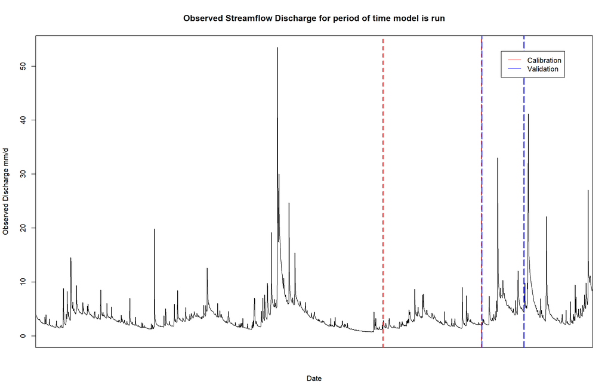

```r
setwd(system.file("extdata/", package = "RHESSysIOinR"))

# Read in RHESSys Calibration runs
#this is only reading in 1 patch

for(i in 1:n) { static_df <- read.csv(paste0("outputfilter/static_basin_daily_",i,".csv"))
  ssurgo_df <- read.csv(paste0("outputfilter/ssurgo_basin_daily_",i,".csv"))
  dsm_df <- read.csv(paste0("outputfilter/dsm_basin_daily_",i,".csv"))

  static_df$date <- as.Date(paste(static_df$year, static_df$month, static_df$day, sep = "-"), format = "%Y-%m-%d")
  ssurgo_df$date <- as.Date(paste(ssurgo_df$year, ssurgo_df$month, ssurgo_df$day, sep = "-"), format = "%Y-%m-%d")
  dsm_df$date <- as.Date(paste(dsm_df$year, dsm_df$month, dsm_df$day, sep = "-"), format = "%Y-%m-%d")

  static_df$patchstreamflow<- static_df$streamflow
  static_df$streamflow<- (static_df$patchstreamflow + static_df$gw.Qout)*1000

  ssurgo_df$patchstreamflow<- ssurgo_df$streamflow
  ssurgo_df$streamflow<- (ssurgo_df$patchstreamflow + ssurgo_df$gw.Qout)*1000

  dsm_df$patchstreamflow<- dsm_df$streamflow
  dsm_df$streamflow<- (dsm_df$patchstreamflow + dsm_df$gw.Qout)*1000

  assign(paste0("cwws32_static_run",i), static_df)
  assign(paste0("cwws32_ssurgo_run",i), ssurgo_df)
  assign(paste0("cwws32_dsm_run",i), dsm_df) }

#Prepare observed Streamflow data

obsws32<- read.csv(paste0(filedir,"input_files/streamflow/Daily Streamflow Watershed 32/Daily Streamflow Watershed 32/ObservedWS32.csv"))

obsws32$Date<- as.Date(obsws32$Date)

Caldates<- read.csv("outputfilter/caldates.csv")
Valdates<- read.csv("outputfilter/valdates.csv")

Caldates<- Caldates[,2]
Valdates<- Valdates[,2]

mergedsm<- read.table("outputfilter/mergedsm.csv", header = T, sep = ",")
obsws32sm<- read.table("outputfilter/obsws32sm.csv", header = T, sep = ",")
obsws32sm$Date<- as.Date(obsws32sm$Date,"%Y-%m-%d")

## plot observed data for period of record and calibration/validation periods as defined by SM data
{plot(obsws32$Date,obsws32$discharge_mm, type = 'l', xlim=c(as.Date(input_rhessys_static$start_date, "%Y%m%d"),as.Date(input_rhessys_static$end_date, "%Y%m%d")),ylab = "Observed Discharge mm/d", xlab = "Date", main = "Observed Streamflow Discharge for period of time model is run")
abline(v=as.Date(Caldates[1]), col = 'red', lwd = 2, lty = 2)
abline(v=as.Date(Caldates[2]), col = 'red', lwd = 2, lty = 2)
abline(v=as.Date(Valdates[1]), col = 'blue', lwd = 2, lty = 5)
abline(v=as.Date(Valdates[2]), col = 'blue', lwd = 2, lty = 5)
legend("topright",inset = 0.05, legend=c("Calibration","Validation"), col=c("red","blue"), lty=1)}
```

Calculate calibration performance metrics for STATIC

using

rootzone.S/rootzone.field_capacity for soil moisture vwc

#must change to *

```r
setwd(system.file("extdata/", package = "RHESSysIOinR"))

#creates cal subset, val subset, and merged streamflow

for(i in 1:n) { assign(paste0("simmerge",i), merge(obsws32,eval(parse(text = paste0("cwws32_static_run",i))), by.x = "Date", by.y="date", all = FALSE))
  assign(paste0("simmergesm",i), merge(obsws32sm,eval(parse(text = paste0("cwws32_static_run",i))), by.x = "Date",by.y="date", all = FALSE))
  assign(paste0("calsubset",i),eval(parse(text = paste0("simmerge",i)))[eval(parse(text = paste0("simmerge",i,"$Date"))) >= Caldates[1] & eval(parse(text = paste0("simmerge",i,"$Date"))) <= Caldates[2], ])
  assign(paste0("valsubset",i),eval(parse(text = paste0("simmerge",i)))[eval(parse(text = paste0("simmerge",i,"$Date"))) >= Valdates[1] & eval(parse(text = paste0("simmerge",i,"$Date"))) <= Valdates[2], ])
  assign(paste0("calsubsetsm",i),eval(parse(text = paste0("simmergesm",i)))[eval(parse(text = paste0("simmergesm",i,"$Date"))) >= Caldates[1] & eval(parse(text = paste0("simmerge",i,"$Date"))) <= Caldates[2], ])
  assign(paste0("valsubsetsm",i),eval(parse(text = paste0("simmergesm",i)))[eval(parse(text = paste0("simmergesm",i,"$Date"))) >= Valdates[1] & eval(parse(text = paste0("simmerge",i,"$Date"))) <= Valdates[2], ])}

## create lists

NSElist <- lnNSElist <- KGElist <- smNSElist <- smlnNSElist <- smKGElist <- list()

for(i in 1:n) { assign(paste0("NSEobs",i), NSE(sim = as.numeric(eval(parse(text = paste0("simmerge",i,"$streamflow")))), obs = as.numeric(eval(parse(text = paste0("simmerge",i,"$observedstreamflow")))) ))
  NSElist[[i]]<- eval(parse(text = paste0("NSEobs",i))) }

for(i in 1:n) {  assign(paste0("lnNSEobs",i), NSE( sim = as.numeric(eval(parse(text = paste0("simmerge",i,"$streamflow")))), obs = as.numeric(eval(parse(text = paste0("simmerge",i,"$observedstreamflow")))), FUN = log, epsilon = "Pushpalatha2012", na.rm=TRUE))
  lnNSElist[[i]]<- eval(parse(text = paste0("lnNSEobs",i))) }

for(i in 1:n) {  assign(paste0("KGEobs",i), KGE(sim = as.numeric(eval(parse(text = paste0("simmerge",i,"$streamflow")))), obs = as.numeric(eval(parse(text = paste0("simmerge",i,"$observedstreamflow"))))))
  KGElist[[i]]<- eval(parse(text = paste0("KGEobs",i))) }

for(i in 1:n) {  assign(paste0("smNSEobs",i), NSE(sim = as.numeric(eval(parse(text = paste0("simmergesm",i,"$rootzone.S","*simmergesm",i,"$rootzone.field_capacity")))), obs = as.numeric(eval(parse(text = paste0("simmergesm",i,"$mergedsoilmoisture"))))))
  smNSElist[[i]]<- eval(parse(text = paste0("smNSEobs",i))) }

for(i in 1:n) {  assign(paste0("smlnNSEobs",i), NSE(sim = as.numeric(eval(parse(text = paste0("simmergesm",i,"$rootzone.S","*simmergesm",i,"$rootzone.field_capacity")))), obs = as.numeric(eval(parse(text = paste0("simmergesm",i,"$mergedsoilmoisture")))), FUN = log, epsilon = "Pushpalatha2012", na.rm=TRUE))
  smlnNSElist[[i]]<- eval(parse(text = paste0("smlnNSEobs",i))) }

for(i in 1:n) {  assign(paste0("smKGEobs",i), KGE(sim = as.numeric(eval(parse(text = paste0("simmergesm",i,"$rootzone.S","*simmergesm",i,"$rootzone.field_capacity")))), obs = as.numeric(eval(parse(text = paste0("simmergesm",i,"$mergedsoilmoisture"))))))
  smKGElist[[i]]<- eval(parse(text = paste0("smKGEobs",i))) }

## modified for calsubset

calNSElist<- callnNSElist <- calKGElist <- calsmNSElist<- calsmlnNSElist<- calsmKGElist<- list()

for(i in 1:n) { assign(paste0("cNSEobs",i), NSE(sim = as.numeric(eval(parse(text = paste0("calsubset",i,"$streamflow")))), obs = as.numeric(eval(parse(text = paste0("calsubset",i,"$observedstreamflow")))) ))
  calNSElist[[i]]<- eval(parse(text = paste0("cNSEobs",i))) }

for(i in 1:n) {  assign(paste0("clnNSEobs",i), NSE( sim = as.numeric(eval(parse(text = paste0("calsubset",i,"$streamflow")))), obs = as.numeric(eval(parse(text = paste0("calsubset",i,"$observedstreamflow")))), FUN = log, epsilon = "Pushpalatha2012", na.rm=TRUE))
  callnNSElist[[i]]<- eval(parse(text = paste0("clnNSEobs",i))) }

for(i in 1:n) {  assign(paste0("cKGEobs",i), KGE(sim = as.numeric(eval(parse(text = paste0("calsubset",i,"$streamflow")))), obs = as.numeric(eval(parse(text = paste0("calsubset",i,"$observedstreamflow"))))))
  calKGElist[[i]]<- eval(parse(text = paste0("cKGEobs",i))) }

for(i in 1:n) {  assign(paste0("csmNSEobs",i), NSE(sim = as.numeric(eval(parse(text = paste0("calsubsetsm",i,"$rootzone.S","*calsubsetsm",i,"$rootzone.field_capacity")))), obs = as.numeric(eval(parse(text = paste0("calsubsetsm",i,"$mergedsoilmoisture"))))))
  calsmNSElist[[i]]<- eval(parse(text = paste0("csmNSEobs",i))) }

for(i in 1:n) {  assign(paste0("csmlnNSEobs",i), NSE(sim = as.numeric(eval(parse(text = paste0("calsubsetsm",i,"$rootzone.S","*calsubsetsm",i,"$rootzone.field_capacity")))), obs = as.numeric(eval(parse(text = paste0("calsubsetsm",i,"$mergedsoilmoisture")))), FUN = log, epsilon = "Pushpalatha2012", na.rm=TRUE))
  calsmlnNSElist[[i]]<- eval(parse(text = paste0("csmlnNSEobs",i))) }

for(i in 1:n) {  assign(paste0("csmKGEobs",i), KGE(sim = as.numeric(eval(parse(text = paste0("calsubsetsm",i,"$rootzone.S","*calsubsetsm",i,"$rootzone.field_capacity")))), obs = as.numeric(eval(parse(text = paste0("calsubsetsm",i,"$mergedsoilmoisture"))))))
  calsmKGElist[[i]]<- eval(parse(text = paste0("csmKGEobs",i))) }

## modified for val subset

valNSElist<- vallnNSElist<- valKGElist<- valsmNSElist <- valsmlnNSElist<- valsmKGElist <- list()

for(i in 1:n) { assign(paste0("vNSEobs",i), NSE(sim = as.numeric(eval(parse(text = paste0("valsubset",i,"$streamflow")))), obs = as.numeric(eval(parse(text = paste0("valsubset",i,"$observedstreamflow")))) ))
  valNSElist[[i]]<- eval(parse(text = paste0("vNSEobs",i))) }

for(i in 1:n) {  assign(paste0("vlnNSEobs",i), NSE( sim = as.numeric(eval(parse(text = paste0("valsubset",i,"$streamflow")))), obs = as.numeric(eval(parse(text = paste0("valsubset",i,"$observedstreamflow")))), FUN = log, epsilon = "Pushpalatha2012", na.rm=TRUE))
  vallnNSElist[[i]]<- eval(parse(text = paste0("vlnNSEobs",i))) }

for(i in 1:n) {  assign(paste0("vKGEobs",i), KGE(sim = as.numeric(eval(parse(text = paste0("valsubset",i,"$streamflow")))), obs = as.numeric(eval(parse(text = paste0("valsubset",i,"$observedstreamflow"))))))
  valKGElist[[i]]<- eval(parse(text = paste0("vKGEobs",i))) }

for(i in 1:n) {  assign(paste0("vsmNSEobs",i), NSE(sim = as.numeric(eval(parse(text = paste0("valsubsetsm",i,"$rootzone.S","*valsubsetsm",i,"$rootzone.field_capacity")))), obs = as.numeric(eval(parse(text = paste0("valsubsetsm",i,"$mergedsoilmoisture"))))))
  valsmNSElist[[i]]<- eval(parse(text = paste0("vsmNSEobs",i))) }

for(i in 1:n) {  assign(paste0("vsmlnNSEobs",i), NSE(sim = as.numeric(eval(parse(text = paste0("valsubsetsm",i,"$rootzone.S","*valsubsetsm",i,"$rootzone.field_capacity")))), obs = as.numeric(eval(parse(text = paste0("valsubsetsm",i,"$mergedsoilmoisture")))), FUN = log, epsilon = "Pushpalatha2012", na.rm=TRUE))
  valsmlnNSElist[[i]]<- eval(parse(text = paste0("vsmlnNSEobs",i))) }

for(i in 1:n) {  assign(paste0("vsmKGEobs",i), KGE(sim = as.numeric(eval(parse(text = paste0("valsubsetsm",i,"$rootzone.S","*valsubsetsm",i,"$rootzone.field_capacity")))), obs = as.numeric(eval(parse(text = paste0("valsubsetsm",i,"$mergedsoilmoisture"))))))
  valsmKGElist[[i]]<- eval(parse(text = paste0("vsmKGEobs",i))) }

Reduce(max, NSElist)
```

```
## [1] 0.5679355
```

```r
Reduce(max, lnNSElist)
```

```
## [1] 0.5242326
```

```r
Reduce(max, KGElist)
```

```
## [1] 0.6847616
```

```r
Reduce(max, smNSElist)
```

```
## [1] -5.961128
```

```r
Reduce(max, smlnNSElist)
```

```
## [1] -9.168643
```

```r
Reduce(max, smKGElist)
```

```
## [1] 0.05492179
```

```r
which(NSElist == Reduce(max, NSElist), arr.ind=TRUE)
```

```
## [1] 14
```

```r
which(lnNSElist == Reduce(max, lnNSElist), arr.ind=TRUE)
```

```
## [1] 14
```

```r
which(KGElist == Reduce(max, KGElist), arr.ind=TRUE)
```

```
## [1] 21
```

```r
which(smNSElist == Reduce(max, smNSElist), arr.ind=TRUE)
```

```
## [1] 23
```

```r
which(smlnNSElist == Reduce(max, smlnNSElist), arr.ind=TRUE)
```

```
## [1] 23
```

```r
which(smKGElist == Reduce(max, smKGElist), arr.ind=TRUE)
```

```
## [1] 5
```

```r
paramtable<- read.table(file = "out/cwparamtable.txt")

paramtable[which(NSElist == Reduce(max, NSElist), arr.ind=TRUE),]
```

```
##             m        k soil_dep      m_v      k_v       gw1       gw2        pa
## 8494 7.107695 25.91582 1.643848 1.287746 7.390301 0.2525454 0.4770451 0.3592307
##            po  vgseng1   vgseng2  vgseng3
## 8494 1.103111 1.498004 0.3841598 1.122217
```

```r
paramtable[which(lnNSElist == Reduce(max, lnNSElist), arr.ind=TRUE),]
```

```
##             m        k soil_dep      m_v      k_v       gw1       gw2        pa
## 8494 7.107695 25.91582 1.643848 1.287746 7.390301 0.2525454 0.4770451 0.3592307
##            po  vgseng1   vgseng2  vgseng3
## 8494 1.103111 1.498004 0.3841598 1.122217
```

```r
paramtable[which(KGElist == Reduce(max, KGElist), arr.ind=TRUE),]
```

```
##             m        k soil_dep      m_v      k_v        gw1        gw2
## 3951 2.120146 51.39124 0.578524 10.98745 14.86183 0.03789263 0.04344977
##             pa       po  vgseng1   vgseng2  vgseng3
## 3951 0.1064449 1.584611 1.311211 0.7606358 1.073991
```

```r
paramtable[which(smNSElist == Reduce(max, smNSElist), arr.ind=TRUE),]
```

```
##             m        k  soil_dep      m_v      k_v       gw1       gw2
## 1929 7.658168 61.17758 0.7090951 10.12554 1.224369 0.2195068 0.5063794
##             pa       po  vgseng1  vgseng2   vgseng3
## 1929 0.7620216 1.048394 1.241617 1.297863 0.2541754
```

```r
paramtable[which(smlnNSElist == Reduce(max, smlnNSElist), arr.ind=TRUE),]
```

```
##             m        k  soil_dep      m_v      k_v       gw1       gw2
## 1929 7.658168 61.17758 0.7090951 10.12554 1.224369 0.2195068 0.5063794
##             pa       po  vgseng1  vgseng2   vgseng3
## 1929 0.7620216 1.048394 1.241617 1.297863 0.2541754
```

```r
paramtable[which(smKGElist == Reduce(max, smKGElist), arr.ind=TRUE),]
```

```
##              m        k soil_dep      m_v      k_v       gw1       gw2
## 2351 0.2766159 51.53632 1.176407 2.475784 2.136945 0.2761841 0.2385695
##             pa       po  vgseng1  vgseng2  vgseng3
## 2351 0.4128614 1.442304 1.961214 1.480393 1.320251
```

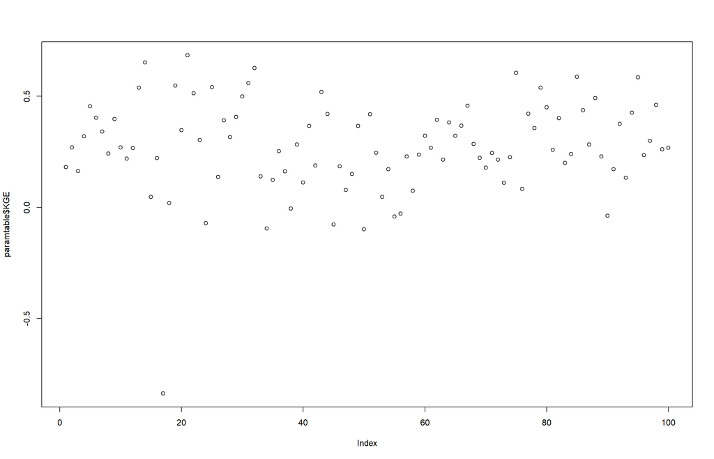

```r
###plot all data for GLUE

paramtable$run<- seq.int(nrow(paramtable))
paramtable$rowname<- row.names(paramtable)

paramtable$NSE<- NSElist
paramtable$lnNSE<- lnNSElist
paramtable$KGE<- KGElist

paramtable$smNSE<- smNSElist
paramtable$smlnNSE<- smlnNSElist
paramtable$smKGE<- smKGElist

#add in calibration values

paramtable$calNSE<- calNSElist
paramtable$callnNSE<- callnNSElist
paramtable$calKGE<- calKGElist

paramtable$calsmNSE<- calsmNSElist
paramtable$calsmlnNSE<- calsmlnNSElist
paramtable$calsmKGE<- calsmKGElist

#add in validation values
paramtable$valNSE<- valNSElist
paramtable$vallnNSE<- vallnNSElist
paramtable$valKGE<- valKGElist

paramtable$valsmNSE<- valsmNSElist
paramtable$valsmlnNSE<- valsmlnNSElist
paramtable$valsmKGE<- valsmKGElist

paramtable<- as.data.frame(lapply(paramtable,unlist))


plot(paramtable$KGE)
```

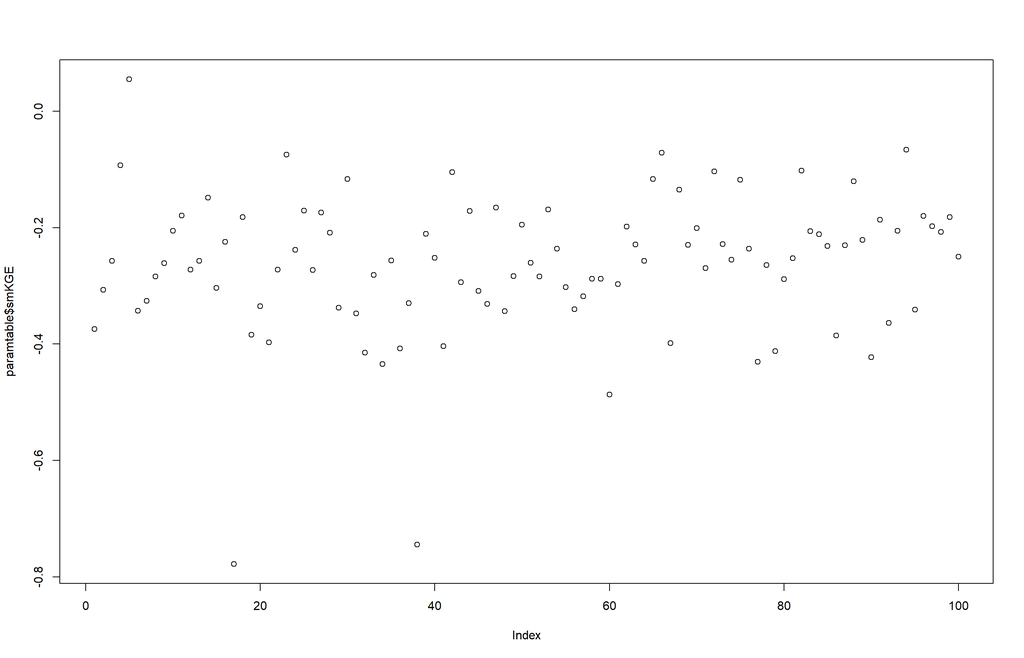

```r
plot(paramtable$smKGE)
```

```r
write.table(paramtable, file = "out/staticcalibrationoutput.txt")
```

Calculate calibration performance metrics for SSURGO

using

rootzone.S/rootzone.field_capacity for soil moisture vwc

```r
setwd(system.file("extdata/", package = "RHESSysIOinR"))

##merge calibration runs with observed so dates match up, instead of subsetting

#creates cal subset, val subset, and merged streamflow

for(i in 1:n) { assign(paste0("simmerge",i), merge(obsws32,eval(parse(text = paste0("cwws32_ssurgo_run",i))), by.x = "Date", by.y="date", all = FALSE))
  assign(paste0("simmergesm",i), merge(obsws32sm,eval(parse(text = paste0("cwws32_ssurgo_run",i))), by.x = "Date",by.y="date", all = FALSE))
  assign(paste0("calsubset",i),eval(parse(text = paste0("simmerge",i)))[eval(parse(text = paste0("simmerge",i,"$Date"))) >= Caldates[1] & eval(parse(text = paste0("simmerge",i,"$Date"))) <= Caldates[2], ])
  assign(paste0("valsubset",i),eval(parse(text = paste0("simmerge",i)))[eval(parse(text = paste0("simmerge",i,"$Date"))) >= Valdates[1] & eval(parse(text = paste0("simmerge",i,"$Date"))) <= Valdates[2], ])
  assign(paste0("calsubsetsm",i),eval(parse(text = paste0("simmergesm",i)))[eval(parse(text = paste0("simmergesm",i,"$Date"))) >= Caldates[1] & eval(parse(text = paste0("simmerge",i,"$Date"))) <= Caldates[2], ])
  assign(paste0("valsubsetsm",i),eval(parse(text = paste0("simmergesm",i)))[eval(parse(text = paste0("simmergesm",i,"$Date"))) >= Valdates[1] & eval(parse(text = paste0("simmerge",i,"$Date"))) <= Valdates[2], ])}

## create lists


NSElist <- lnNSElist <- KGElist <- smNSElist <- smlnNSElist <- smKGElist <- list()

for(i in 1:n) { assign(paste0("NSEobs",i), NSE(sim = as.numeric(eval(parse(text = paste0("simmerge",i,"$streamflow")))), obs = as.numeric(eval(parse(text = paste0("simmerge",i,"$observedstreamflow")))) ))
  NSElist[[i]]<- eval(parse(text = paste0("NSEobs",i))) }

for(i in 1:n) {  assign(paste0("lnNSEobs",i), NSE( sim = as.numeric(eval(parse(text = paste0("simmerge",i,"$streamflow")))), obs = as.numeric(eval(parse(text = paste0("simmerge",i,"$observedstreamflow")))), FUN = log, epsilon = "Pushpalatha2012", na.rm=TRUE))
  lnNSElist[[i]]<- eval(parse(text = paste0("lnNSEobs",i))) }

for(i in 1:n) {  assign(paste0("KGEobs",i), KGE(sim = as.numeric(eval(parse(text = paste0("simmerge",i,"$streamflow")))), obs = as.numeric(eval(parse(text = paste0("simmerge",i,"$observedstreamflow"))))))
  KGElist[[i]]<- eval(parse(text = paste0("KGEobs",i))) }

for(i in 1:n) {  assign(paste0("smNSEobs",i), NSE(sim = as.numeric(eval(parse(text = paste0("simmergesm",i,"$rootzone.S","*simmergesm",i,"$rootzone.field_capacity")))), obs = as.numeric(eval(parse(text = paste0("simmergesm",i,"$mergedsoilmoisture"))))))
  smNSElist[[i]]<- eval(parse(text = paste0("smNSEobs",i))) }

for(i in 1:n) {  assign(paste0("smlnNSEobs",i), NSE(sim = as.numeric(eval(parse(text = paste0("simmergesm",i,"$rootzone.S","*simmergesm",i,"$rootzone.field_capacity")))), obs = as.numeric(eval(parse(text = paste0("simmergesm",i,"$mergedsoilmoisture")))), FUN = log, epsilon = "Pushpalatha2012", na.rm=TRUE))
  smlnNSElist[[i]]<- eval(parse(text = paste0("smlnNSEobs",i))) }

for(i in 1:n) {  assign(paste0("smKGEobs",i), KGE(sim = as.numeric(eval(parse(text = paste0("simmergesm",i,"$rootzone.S","*simmergesm",i,"$rootzone.field_capacity")))), obs = as.numeric(eval(parse(text = paste0("simmergesm",i,"$mergedsoilmoisture"))))))
  smKGElist[[i]]<- eval(parse(text = paste0("smKGEobs",i))) }

## modified for calsubset

calNSElist<- callnNSElist <- calKGElist <- calsmNSElist<- calsmlnNSElist<- calsmKGElist<- list()

for(i in 1:n) { assign(paste0("cNSEobs",i), NSE(sim = as.numeric(eval(parse(text = paste0("calsubset",i,"$streamflow")))), obs = as.numeric(eval(parse(text = paste0("calsubset",i,"$observedstreamflow")))) ))
  calNSElist[[i]]<- eval(parse(text = paste0("cNSEobs",i))) }

for(i in 1:n) {  assign(paste0("clnNSEobs",i), NSE( sim = as.numeric(eval(parse(text = paste0("calsubset",i,"$streamflow")))), obs = as.numeric(eval(parse(text = paste0("calsubset",i,"$observedstreamflow")))), FUN = log, epsilon = "Pushpalatha2012", na.rm=TRUE))
  callnNSElist[[i]]<- eval(parse(text = paste0("clnNSEobs",i))) }

for(i in 1:n) {  assign(paste0("cKGEobs",i), KGE(sim = as.numeric(eval(parse(text = paste0("calsubset",i,"$streamflow")))), obs = as.numeric(eval(parse(text = paste0("calsubset",i,"$observedstreamflow"))))))
  calKGElist[[i]]<- eval(parse(text = paste0("cKGEobs",i))) }

for(i in 1:n) {  assign(paste0("csmNSEobs",i), NSE(sim = as.numeric(eval(parse(text = paste0("calsubsetsm",i,"$rootzone.S","*calsubsetsm",i,"$rootzone.field_capacity")))), obs = as.numeric(eval(parse(text = paste0("calsubsetsm",i,"$mergedsoilmoisture"))))))
  calsmNSElist[[i]]<- eval(parse(text = paste0("csmNSEobs",i))) }

for(i in 1:n) {  assign(paste0("csmlnNSEobs",i), NSE(sim = as.numeric(eval(parse(text = paste0("calsubsetsm",i,"$rootzone.S","*calsubsetsm",i,"$rootzone.field_capacity")))), obs = as.numeric(eval(parse(text = paste0("calsubsetsm",i,"$mergedsoilmoisture")))), FUN = log, epsilon = "Pushpalatha2012", na.rm=TRUE))
  calsmlnNSElist[[i]]<- eval(parse(text = paste0("csmlnNSEobs",i))) }

for(i in 1:n) {  assign(paste0("csmKGEobs",i), KGE(sim = as.numeric(eval(parse(text = paste0("calsubsetsm",i,"$rootzone.S","*calsubsetsm",i,"$rootzone.field_capacity")))), obs = as.numeric(eval(parse(text = paste0("calsubsetsm",i,"$mergedsoilmoisture"))))))
  calsmKGElist[[i]]<- eval(parse(text = paste0("csmKGEobs",i))) }

## modified for val subset

valNSElist<- vallnNSElist<- valKGElist<- valsmNSElist <- valsmlnNSElist<- valsmKGElist <- list()

for(i in 1:n) { assign(paste0("vNSEobs",i), NSE(sim = as.numeric(eval(parse(text = paste0("valsubset",i,"$streamflow")))), obs = as.numeric(eval(parse(text = paste0("valsubset",i,"$observedstreamflow")))) ))
  valNSElist[[i]]<- eval(parse(text = paste0("vNSEobs",i))) }

for(i in 1:n) {  assign(paste0("vlnNSEobs",i), NSE( sim = as.numeric(eval(parse(text = paste0("valsubset",i,"$streamflow")))), obs = as.numeric(eval(parse(text = paste0("valsubset",i,"$observedstreamflow")))), FUN = log, epsilon = "Pushpalatha2012", na.rm=TRUE))
  vallnNSElist[[i]]<- eval(parse(text = paste0("vlnNSEobs",i))) }

for(i in 1:n) {  assign(paste0("vKGEobs",i), KGE(sim = as.numeric(eval(parse(text = paste0("valsubset",i,"$streamflow")))), obs = as.numeric(eval(parse(text = paste0("valsubset",i,"$observedstreamflow"))))))
  valKGElist[[i]]<- eval(parse(text = paste0("vKGEobs",i))) }

for(i in 1:n) {  assign(paste0("vsmNSEobs",i), NSE(sim = as.numeric(eval(parse(text = paste0("valsubsetsm",i,"$rootzone.S","*valsubsetsm",i,"$rootzone.field_capacity")))), obs = as.numeric(eval(parse(text = paste0("valsubsetsm",i,"$mergedsoilmoisture"))))))
  valsmNSElist[[i]]<- eval(parse(text = paste0("vsmNSEobs",i))) }

for(i in 1:n) {  assign(paste0("vsmlnNSEobs",i), NSE(sim = as.numeric(eval(parse(text = paste0("valsubsetsm",i,"$rootzone.S","*valsubsetsm",i,"$rootzone.field_capacity")))), obs = as.numeric(eval(parse(text = paste0("valsubsetsm",i,"$mergedsoilmoisture")))), FUN = log, epsilon = "Pushpalatha2012", na.rm=TRUE))
  valsmlnNSElist[[i]]<- eval(parse(text = paste0("vsmlnNSEobs",i))) }

for(i in 1:n) {  assign(paste0("vsmKGEobs",i), KGE(sim = as.numeric(eval(parse(text = paste0("valsubsetsm",i,"$rootzone.S","*valsubsetsm",i,"$rootzone.field_capacity")))), obs = as.numeric(eval(parse(text = paste0("valsubsetsm",i,"$mergedsoilmoisture"))))))
  valsmKGElist[[i]]<- eval(parse(text = paste0("vsmKGEobs",i))) }

Reduce(max, NSElist)
```

```
## [1] 0.5191775
```

```r
Reduce(max, lnNSElist)
```

```
## [1] 0.3901672
```

```r
Reduce(max, KGElist)
```

```
## [1] 0.7162451
```

```r
Reduce(max, smNSElist)
```

```
## [1] -18.33976
```

```r
Reduce(max, smlnNSElist)
```

```
## [1] -47.57662
```

```r
Reduce(max, smKGElist)
```

```
## [1] -0.2093209
```

```r
which(NSElist == Reduce(max, NSElist), arr.ind=TRUE)
```

```
## [1] 19
```

```r
which(lnNSElist == Reduce(max, lnNSElist), arr.ind=TRUE)
```

```
## [1] 19
```

```r
which(KGElist == Reduce(max, KGElist), arr.ind=TRUE)
```

```
## [1] 20
```

```r
which(smNSElist == Reduce(max, smNSElist), arr.ind=TRUE)
```

```
## [1] 23
```

```r
which(smlnNSElist == Reduce(max, smlnNSElist), arr.ind=TRUE)
```

```
## [1] 23
```

```r
which(smKGElist == Reduce(max, smKGElist), arr.ind=TRUE)
```

```
## [1] 38
```

```r
paramtable<- read.table(file = "out/cwparamtable.txt")

paramtable[which(NSElist == Reduce(max, NSElist), arr.ind=TRUE),]
```

```
##             m        k soil_dep      m_v      k_v       gw1       gw2        pa
## 5615 1.410735 30.83061 1.382676 5.852734 3.726986 0.2816848 0.2575848 0.2916331
##            po  vgseng1  vgseng2  vgseng3
## 5615 1.859008 1.279521 1.123132 1.754444
```

```r
paramtable[which(lnNSElist == Reduce(max, lnNSElist), arr.ind=TRUE),]
```

```
##             m        k soil_dep      m_v      k_v       gw1       gw2        pa
## 5615 1.410735 30.83061 1.382676 5.852734 3.726986 0.2816848 0.2575848 0.2916331
##            po  vgseng1  vgseng2  vgseng3
## 5615 1.859008 1.279521 1.123132 1.754444
```

```r
paramtable[which(KGElist == Reduce(max, KGElist), arr.ind=TRUE),]
```

```
##             m        k soil_dep      m_v      k_v       gw1       gw2        pa
## 1081 3.192353 3.802293 1.727122 5.974606 3.861233 0.2601113 0.4437058 0.5579785
##            po  vgseng1  vgseng2   vgseng3
## 1081 1.521729 1.832505 1.102582 0.5133313
```

```r
paramtable[which(smNSElist == Reduce(max, smNSElist), arr.ind=TRUE),]
```

```
##             m        k  soil_dep      m_v      k_v       gw1       gw2
## 1929 7.658168 61.17758 0.7090951 10.12554 1.224369 0.2195068 0.5063794
##             pa       po  vgseng1  vgseng2   vgseng3
## 1929 0.7620216 1.048394 1.241617 1.297863 0.2541754
```

```r
paramtable[which(smlnNSElist == Reduce(max, smlnNSElist), arr.ind=TRUE),]
```

```
##             m        k  soil_dep      m_v      k_v       gw1       gw2
## 1929 7.658168 61.17758 0.7090951 10.12554 1.224369 0.2195068 0.5063794
##             pa       po  vgseng1  vgseng2   vgseng3
## 1929 0.7620216 1.048394 1.241617 1.297863 0.2541754
```

```r
paramtable[which(smKGElist == Reduce(max, smKGElist), arr.ind=TRUE),]
```

```
##              m        k soil_dep      m_v     k_v      gw1       gw2        pa
## 1187 0.1359431 94.70758 1.798364 12.68998 7.17253 0.236533 0.1239401 0.6715787
##            po  vgseng1  vgseng2  vgseng3
## 1187 1.367797 1.963257 1.651261 1.816664
```

```r
###plot all data for GLUE

paramtable$run<- seq.int(nrow(paramtable))
paramtable$rowname<- row.names(paramtable)

paramtable$NSE<- NSElist
paramtable$lnNSE<- lnNSElist
paramtable$KGE<- KGElist

paramtable$smNSE<- smNSElist
paramtable$smlnNSE<- smlnNSElist
paramtable$smKGE<- smKGElist

#add in calibration values

paramtable$calNSE<- calNSElist
paramtable$callnNSE<- callnNSElist
paramtable$calKGE<- calKGElist

paramtable$calsmNSE<- calsmNSElist
paramtable$calsmlnNSE<- calsmlnNSElist
paramtable$calsmKGE<- calsmKGElist

#add in validation values
paramtable$valNSE<- valNSElist
paramtable$vallnNSE<- vallnNSElist
paramtable$valKGE<- valKGElist

paramtable$valsmNSE<- valsmNSElist
paramtable$valsmlnNSE<- valsmlnNSElist
paramtable$valsmKGE<- valsmKGElist

paramtable<- as.data.frame(lapply(paramtable,unlist))

write.table(paramtable, file = "out/ssurgocalibrationoutput.txt")
```

Calculate calibration performance metrics for DSM

using

rootzone.S/rootzone.field_capacity for soil moisture vwc

```r
setwd(system.file("extdata/", package = "RHESSysIOinR"))


##merge calibration runs with observed so dates match up, instead of subsetting

#creates cal subset, val subset, and merged streamflow

for(i in 1:n) { assign(paste0("simmerge",i), merge(obsws32,eval(parse(text = paste0("cwws32_dsm_run",i))), by.x = "Date", by.y="date", all = FALSE))
  assign(paste0("simmergesm",i), merge(obsws32sm,eval(parse(text = paste0("cwws32_dsm_run",i))), by.x = "Date",by.y="date", all = FALSE))
  assign(paste0("calsubset",i),eval(parse(text = paste0("simmerge",i)))[eval(parse(text = paste0("simmerge",i,"$Date"))) >= Caldates[1] & eval(parse(text = paste0("simmerge",i,"$Date"))) <= Caldates[2], ])
  assign(paste0("valsubset",i),eval(parse(text = paste0("simmerge",i)))[eval(parse(text = paste0("simmerge",i,"$Date"))) >= Valdates[1] & eval(parse(text = paste0("simmerge",i,"$Date"))) <= Valdates[2], ])
  assign(paste0("calsubsetsm",i),eval(parse(text = paste0("simmergesm",i)))[eval(parse(text = paste0("simmergesm",i,"$Date"))) >= Caldates[1] & eval(parse(text = paste0("simmerge",i,"$Date"))) <= Caldates[2], ])
  assign(paste0("valsubsetsm",i),eval(parse(text = paste0("simmergesm",i)))[eval(parse(text = paste0("simmergesm",i,"$Date"))) >= Valdates[1] & eval(parse(text = paste0("simmerge",i,"$Date"))) <= Valdates[2], ])}

## create lists


NSElist <- lnNSElist <- KGElist <- smNSElist <- smlnNSElist <- smKGElist <- list()

for(i in 1:n) { assign(paste0("NSEobs",i), NSE(sim = as.numeric(eval(parse(text = paste0("simmerge",i,"$streamflow")))), obs = as.numeric(eval(parse(text = paste0("simmerge",i,"$observedstreamflow")))) ))
  NSElist[[i]]<- eval(parse(text = paste0("NSEobs",i))) }

for(i in 1:n) {  assign(paste0("lnNSEobs",i), NSE( sim = as.numeric(eval(parse(text = paste0("simmerge",i,"$streamflow")))), obs = as.numeric(eval(parse(text = paste0("simmerge",i,"$observedstreamflow")))), FUN = log, epsilon = "Pushpalatha2012", na.rm=TRUE))
  lnNSElist[[i]]<- eval(parse(text = paste0("lnNSEobs",i))) }

for(i in 1:n) {  assign(paste0("KGEobs",i), KGE(sim = as.numeric(eval(parse(text = paste0("simmerge",i,"$streamflow")))), obs = as.numeric(eval(parse(text = paste0("simmerge",i,"$observedstreamflow"))))))
  KGElist[[i]]<- eval(parse(text = paste0("KGEobs",i))) }

for(i in 1:n) {  assign(paste0("smNSEobs",i), NSE(sim = as.numeric(eval(parse(text = paste0("simmergesm",i,"$rootzone.S","*simmergesm",i,"$rootzone.field_capacity")))), obs = as.numeric(eval(parse(text = paste0("simmergesm",i,"$mergedsoilmoisture"))))))
  smNSElist[[i]]<- eval(parse(text = paste0("smNSEobs",i))) }

for(i in 1:n) {  assign(paste0("smlnNSEobs",i), NSE(sim = as.numeric(eval(parse(text = paste0("simmergesm",i,"$rootzone.S","*simmergesm",i,"$rootzone.field_capacity")))), obs = as.numeric(eval(parse(text = paste0("simmergesm",i,"$mergedsoilmoisture")))), FUN = log, epsilon = "Pushpalatha2012", na.rm=TRUE))
  smlnNSElist[[i]]<- eval(parse(text = paste0("smlnNSEobs",i))) }

for(i in 1:n) {  assign(paste0("smKGEobs",i), KGE(sim = as.numeric(eval(parse(text = paste0("simmergesm",i,"$rootzone.S","*simmergesm",i,"$rootzone.field_capacity")))), obs = as.numeric(eval(parse(text = paste0("simmergesm",i,"$mergedsoilmoisture"))))))
  smKGElist[[i]]<- eval(parse(text = paste0("smKGEobs",i))) }

## modified for calsubset

calNSElist<- callnNSElist <- calKGElist <- calsmNSElist<- calsmlnNSElist<- calsmKGElist<- list()

for(i in 1:n) { assign(paste0("cNSEobs",i), NSE(sim = as.numeric(eval(parse(text = paste0("calsubset",i,"$streamflow")))), obs = as.numeric(eval(parse(text = paste0("calsubset",i,"$observedstreamflow")))) ))
  calNSElist[[i]]<- eval(parse(text = paste0("cNSEobs",i))) }

for(i in 1:n) {  assign(paste0("clnNSEobs",i), NSE( sim = as.numeric(eval(parse(text = paste0("calsubset",i,"$streamflow")))), obs = as.numeric(eval(parse(text = paste0("calsubset",i,"$observedstreamflow")))), FUN = log, epsilon = "Pushpalatha2012", na.rm=TRUE))
  callnNSElist[[i]]<- eval(parse(text = paste0("clnNSEobs",i))) }

for(i in 1:n) {  assign(paste0("cKGEobs",i), KGE(sim = as.numeric(eval(parse(text = paste0("calsubset",i,"$streamflow")))), obs = as.numeric(eval(parse(text = paste0("calsubset",i,"$observedstreamflow"))))))
  calKGElist[[i]]<- eval(parse(text = paste0("cKGEobs",i))) }

for(i in 1:n) {  assign(paste0("csmNSEobs",i), NSE(sim = as.numeric(eval(parse(text = paste0("calsubsetsm",i,"$rootzone.S","*calsubsetsm",i,"$rootzone.field_capacity")))), obs = as.numeric(eval(parse(text = paste0("calsubsetsm",i,"$mergedsoilmoisture"))))))
  calsmNSElist[[i]]<- eval(parse(text = paste0("csmNSEobs",i))) }

for(i in 1:n) {  assign(paste0("csmlnNSEobs",i), NSE(sim = as.numeric(eval(parse(text = paste0("calsubsetsm",i,"$rootzone.S","*calsubsetsm",i,"$rootzone.field_capacity")))), obs = as.numeric(eval(parse(text = paste0("calsubsetsm",i,"$mergedsoilmoisture")))), FUN = log, epsilon = "Pushpalatha2012", na.rm=TRUE))
  calsmlnNSElist[[i]]<- eval(parse(text = paste0("csmlnNSEobs",i))) }

for(i in 1:n) {  assign(paste0("csmKGEobs",i), KGE(sim = as.numeric(eval(parse(text = paste0("calsubsetsm",i,"$rootzone.S","*calsubsetsm",i,"$rootzone.field_capacity")))), obs = as.numeric(eval(parse(text = paste0("calsubsetsm",i,"$mergedsoilmoisture"))))))
  calsmKGElist[[i]]<- eval(parse(text = paste0("csmKGEobs",i))) }

## modified for val subset

valNSElist<- vallnNSElist<- valKGElist<- valsmNSElist <- valsmlnNSElist<- valsmKGElist <- list()

for(i in 1:n) { assign(paste0("vNSEobs",i), NSE(sim = as.numeric(eval(parse(text = paste0("valsubset",i,"$streamflow")))), obs = as.numeric(eval(parse(text = paste0("valsubset",i,"$observedstreamflow")))) ))
  valNSElist[[i]]<- eval(parse(text = paste0("vNSEobs",i))) }

for(i in 1:n) {  assign(paste0("vlnNSEobs",i), NSE( sim = as.numeric(eval(parse(text = paste0("valsubset",i,"$streamflow")))), obs = as.numeric(eval(parse(text = paste0("valsubset",i,"$observedstreamflow")))), FUN = log, epsilon = "Pushpalatha2012", na.rm=TRUE))
  vallnNSElist[[i]]<- eval(parse(text = paste0("vlnNSEobs",i))) }

for(i in 1:n) {  assign(paste0("vKGEobs",i), KGE(sim = as.numeric(eval(parse(text = paste0("valsubset",i,"$streamflow")))), obs = as.numeric(eval(parse(text = paste0("valsubset",i,"$observedstreamflow"))))))
  valKGElist[[i]]<- eval(parse(text = paste0("vKGEobs",i))) }

for(i in 1:n) {  assign(paste0("vsmNSEobs",i), NSE(sim = as.numeric(eval(parse(text = paste0("valsubsetsm",i,"$rootzone.S","*valsubsetsm",i,"$rootzone.field_capacity")))), obs = as.numeric(eval(parse(text = paste0("valsubsetsm",i,"$mergedsoilmoisture"))))))
  valsmNSElist[[i]]<- eval(parse(text = paste0("vsmNSEobs",i))) }

for(i in 1:n) {  assign(paste0("vsmlnNSEobs",i), NSE(sim = as.numeric(eval(parse(text = paste0("valsubsetsm",i,"$rootzone.S","*valsubsetsm",i,"$rootzone.field_capacity")))), obs = as.numeric(eval(parse(text = paste0("valsubsetsm",i,"$mergedsoilmoisture")))), FUN = log, epsilon = "Pushpalatha2012", na.rm=TRUE))
  valsmlnNSElist[[i]]<- eval(parse(text = paste0("vsmlnNSEobs",i))) }

for(i in 1:n) {  assign(paste0("vsmKGEobs",i), KGE(sim = as.numeric(eval(parse(text = paste0("valsubsetsm",i,"$rootzone.S","*valsubsetsm",i,"$rootzone.field_capacity")))), obs = as.numeric(eval(parse(text = paste0("valsubsetsm",i,"$mergedsoilmoisture"))))))
  valsmKGElist[[i]]<- eval(parse(text = paste0("vsmKGEobs",i))) }

Reduce(max, NSElist)
```

```
## [1] 0.546636
```

```r
Reduce(max, lnNSElist)
```

```
## [1] 0.3525943
```

```r
Reduce(max, KGElist)
```

```
## [1] 0.7114428
```

```r
Reduce(max, smNSElist)
```

```
## [1] -19.03076
```

```r
Reduce(max, smlnNSElist)
```

```
## [1] -51.0699
```

```r
Reduce(max, smKGElist)
```

```
## [1] -0.2378356
```

```r
which(NSElist == Reduce(max, NSElist), arr.ind=TRUE)
```

```
## [1] 85
```

```r
which(lnNSElist == Reduce(max, lnNSElist), arr.ind=TRUE)
```

```
## [1] 19
```

```r
which(KGElist == Reduce(max, KGElist), arr.ind=TRUE)
```

```
## [1] 20
```

```r
which(smNSElist == Reduce(max, smNSElist), arr.ind=TRUE)
```

```
## [1] 23
```

```r
which(smlnNSElist == Reduce(max, smlnNSElist), arr.ind=TRUE)
```

```
## [1] 23
```

```r
which(smKGElist == Reduce(max, smKGElist), arr.ind=TRUE)
```

```
## [1] 38
```

```r
paramtable<- read.table(file = "out/cwparamtable.txt")

paramtable[which(NSElist == Reduce(max, NSElist), arr.ind=TRUE),]
```

```
##             m        k  soil_dep       m_v      k_v       gw1       gw2
## 6159 5.370098 52.72373 0.1573705 0.7459684 10.35425 0.0343746 0.3241657
##             pa       po  vgseng1 vgseng2 vgseng3
## 6159 0.7564442 1.812101 1.490146 1.33589 1.96583
```

```r
paramtable[which(lnNSElist == Reduce(max, lnNSElist), arr.ind=TRUE),]
```

```
##             m        k soil_dep      m_v      k_v       gw1       gw2        pa
## 5615 1.410735 30.83061 1.382676 5.852734 3.726986 0.2816848 0.2575848 0.2916331
##            po  vgseng1  vgseng2  vgseng3
## 5615 1.859008 1.279521 1.123132 1.754444
```

```r
paramtable[which(KGElist == Reduce(max, KGElist), arr.ind=TRUE),]
```

```
##             m        k soil_dep      m_v      k_v       gw1       gw2        pa
## 1081 3.192353 3.802293 1.727122 5.974606 3.861233 0.2601113 0.4437058 0.5579785
##            po  vgseng1  vgseng2   vgseng3
## 1081 1.521729 1.832505 1.102582 0.5133313
```

```r
paramtable[which(smNSElist == Reduce(max, smNSElist), arr.ind=TRUE),]
```

```
##             m        k  soil_dep      m_v      k_v       gw1       gw2
## 1929 7.658168 61.17758 0.7090951 10.12554 1.224369 0.2195068 0.5063794
##             pa       po  vgseng1  vgseng2   vgseng3
## 1929 0.7620216 1.048394 1.241617 1.297863 0.2541754
```

```r
paramtable[which(smlnNSElist == Reduce(max, smlnNSElist), arr.ind=TRUE),]
```

```
##             m        k  soil_dep      m_v      k_v       gw1       gw2
## 1929 7.658168 61.17758 0.7090951 10.12554 1.224369 0.2195068 0.5063794
##             pa       po  vgseng1  vgseng2   vgseng3
## 1929 0.7620216 1.048394 1.241617 1.297863 0.2541754
```

```r
paramtable[which(smKGElist == Reduce(max, smKGElist), arr.ind=TRUE),]
```

```
##              m        k soil_dep      m_v     k_v      gw1       gw2        pa
## 1187 0.1359431 94.70758 1.798364 12.68998 7.17253 0.236533 0.1239401 0.6715787
##            po  vgseng1  vgseng2  vgseng3
## 1187 1.367797 1.963257 1.651261 1.816664
```

```r
###plot all data for GLUE

paramtable$run<- seq.int(nrow(paramtable))
paramtable$rowname<- row.names(paramtable)

paramtable$NSE<- NSElist
paramtable$lnNSE<- lnNSElist
paramtable$KGE<- KGElist

paramtable$smNSE<- smNSElist
paramtable$smlnNSE<- smlnNSElist
paramtable$smKGE<- smKGElist

#add in calibration values

paramtable$calNSE<- calNSElist
paramtable$callnNSE<- callnNSElist
paramtable$calKGE<- calKGElist

paramtable$calsmNSE<- calsmNSElist
paramtable$calsmlnNSE<- calsmlnNSElist
paramtable$calsmKGE<- calsmKGElist

#add in validation values
paramtable$valNSE<- valNSElist
paramtable$vallnNSE<- vallnNSElist
paramtable$valKGE<- valKGElist

paramtable$valsmNSE<- valsmNSElist
paramtable$valsmlnNSE<- valsmlnNSElist
paramtable$valsmKGE<- valsmKGElist

paramtable<- as.data.frame(lapply(paramtable,unlist))

write.table(paramtable, file = "out/dsmcalibrationoutput.txt")
```

```r
top100<- paramtable[order(-paramtable$lnNSE),][1:n,]

top100$run
```

```
##   [1]  19  32  92  31  18  37   7  77  79   4  65 100  53  21  57  12  14  51
##  [19]  68  36  82  61  49  88  15  44  85  20  62  86  67  84  83  76  28  27
##  [37]  80   5  81  38  43   6  60  87  16  78   8   9   3  63  41  13  26  74
##  [55]  98  39  95  29  75  54  17  46  25  56  23  89  30   2  52  97  66  73
##  [73]  70  69  72  10  94  91  48  33  71  96  90  22  93  42   1  35  11  40
##  [91]  45  59  55  50  58  34  24  47  64  99
```

```r
### use values from top 100 run to table of daily streamflow predictions, for each day predict 95% prediction interval and mean then plot
#subset streamflow value for each day - day 1 day 2 etc
#put all values into a table

top100[["run"]]
```

```
##   [1]  19  32  92  31  18  37   7  77  79   4  65 100  53  21  57  12  14  51
##  [19]  68  36  82  61  49  88  15  44  85  20  62  86  67  84  83  76  28  27
##  [37]  80   5  81  38  43   6  60  87  16  78   8   9   3  63  41  13  26  74
##  [55]  98  39  95  29  75  54  17  46  25  56  23  89  30   2  52  97  66  73
##  [73]  70  69  72  10  94  91  48  33  71  96  90  22  93  42   1  35  11  40
##  [91]  45  59  55  50  58  34  24  47  64  99
```

```r
toppredictions<- data.frame(cwws32_dsm_run1$date)

for (i in top100$run){
 # print(i)
  toppredictions[,ncol(toppredictions)+1] <- eval(parse(text=paste0("cwws32_dsm_run",i,"$streamflow")))
  colnames(toppredictions)[ncol(toppredictions)] <- paste0("stream",i)
}

head(toppredictions[1:5,])
```

```
##   cwws32_dsm_run1.date stream19 stream32 stream92 stream31 stream18 stream37
## 1           2015-11-01    5.133    5.379    4.468    4.684    2.967    4.200
## 2           2015-11-02    8.169   10.025    8.431    9.502    4.573    6.845
## 3           2015-11-03    7.577    7.802    5.722    7.176    3.907    5.682
## 4           2015-11-04    6.858    6.973    5.011    6.328    3.618    5.212
## 5           2015-11-05    6.517    6.705    4.958    6.236    3.539    5.032
##   stream7 stream77 stream79 stream4 stream65 stream100 stream53 stream21
## 1   4.554    4.671    4.404   4.366    4.395     3.734    3.231    3.571
## 2   6.974   10.480    7.109   7.286    7.453     7.038    5.974    8.148
## 3   7.292    7.785    7.048   6.623    6.912     5.327    4.588    6.395
## 4   6.607    7.050    6.373   5.827    6.015     4.732    4.069    6.127
## 5   6.220    7.059    6.062   5.368    5.496     4.543    3.946    6.291
##   stream57 stream12 stream14 stream51 stream68 stream36 stream82 stream61
## 1    3.929    4.110    4.560    4.038    2.830    3.703    3.400    3.743
## 2    7.227    7.183    7.278    7.353    5.363    8.104    7.331    7.321
```

[output cut: 63 more lines]

```r
toppredictions<- toppredictions[,-1]

toppredictions$upper<- 0
toppredictions$mean<- 0
toppredictions$lower<- 0

for (i in 1:nrow(toppredictions)){
 #  print(i)
  upper= CI(as.numeric(toppredictions[i,]),ci=0.95)[1]
  mean= CI(as.numeric(toppredictions[i,]),ci=0.95)[2]
  lower= CI(as.numeric(toppredictions[i,]),ci=0.95)[3]

  toppredictions[i,]$upper<- upper
  toppredictions[i,]$mean<- mean
  toppredictions[i,]$lower<- lower
}

toppredictions<-cbind(date = cwws32_dsm_run1$date,toppredictions)

head(toppredictions[1:5,])
```

```
##         date stream19 stream32 stream92 stream31 stream18 stream37 stream7
## 1 2015-11-01    5.133    5.379    4.468    4.684    2.967    4.200   4.554
## 2 2015-11-02    8.169   10.025    8.431    9.502    4.573    6.845   6.974
## 3 2015-11-03    7.577    7.802    5.722    7.176    3.907    5.682   7.292
## 4 2015-11-04    6.858    6.973    5.011    6.328    3.618    5.212   6.607
## 5 2015-11-05    6.517    6.705    4.958    6.236    3.539    5.032   6.220
##   stream77 stream79 stream4 stream65 stream100 stream53 stream21 stream57
## 1    4.671    4.404   4.366    4.395     3.734    3.231    3.571    3.929
## 2   10.480    7.109   7.286    7.453     7.038    5.974    8.148    7.227
## 3    7.785    7.048   6.623    6.912     5.327    4.588    6.395    5.934
## 4    7.050    6.373   5.827    6.015     4.732    4.069    6.127    5.384
## 5    7.059    6.062   5.368    5.496     4.543    3.946    6.291    5.256
##   stream12 stream14 stream51 stream68 stream36 stream82 stream61 stream49
## 1    4.110    4.560    4.038    2.830    3.703    3.400    3.743    3.937
## 2    7.183    7.278    7.353    5.363    8.104    7.331    7.321    7.803
```

[output cut: 63 more lines]

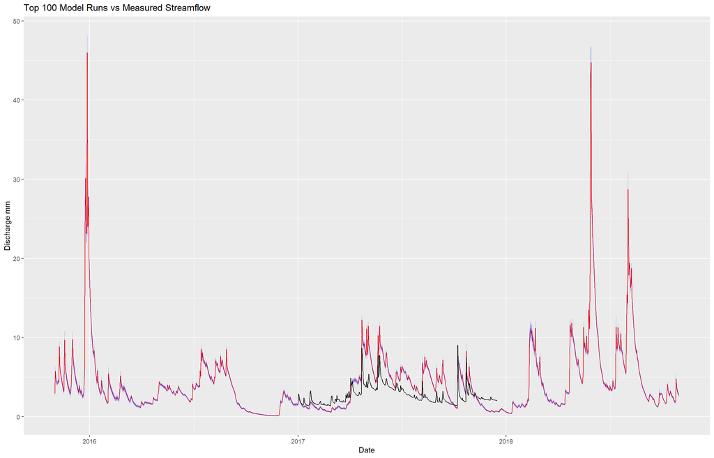

```r
# toppredictions[1:500,]

ggplot(toppredictions,aes(date,mean,group=1))+
  geom_line(col = 'red')+
  geom_ribbon(aes(ymin=lower, ymax=upper), fill = "blue", alpha=0.3)+
  geom_line(data=calsubset1,aes(x=Date,y=discharge_mm))+
  ylab("Discharge mm")+
  xlab("Date")+
  labs(title = "Top 100 Model Runs vs Measured Streamflow")
```

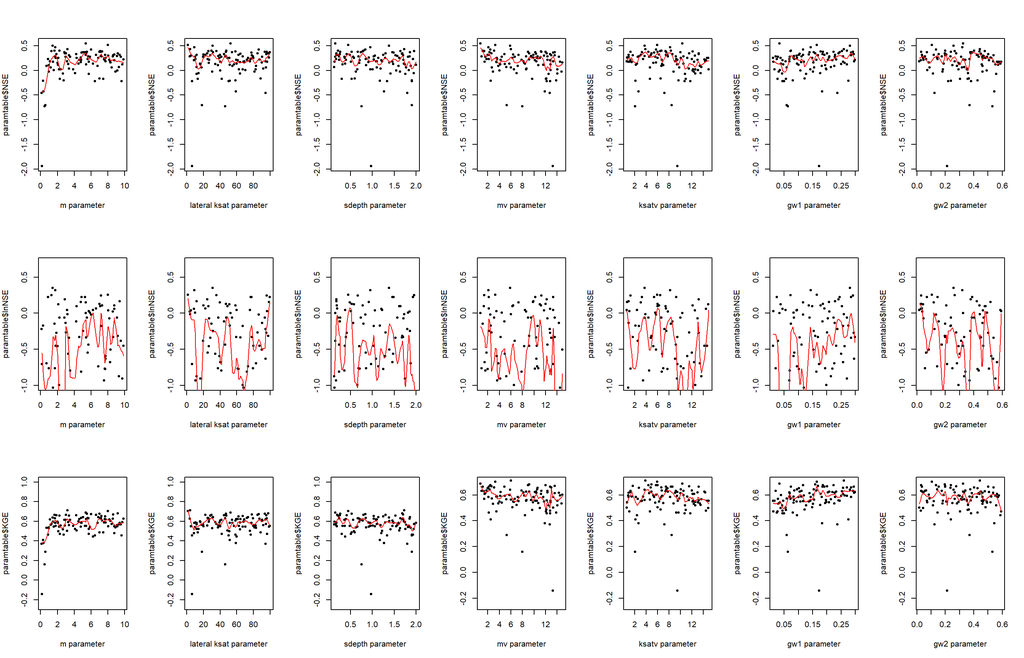

```r
par(mfrow=c(1, 1))

old.par <- par(mfrow=c(3, 7), mar = c(5,4,4,2))

{plot(paramtable$m,paramtable$NSE,xlab = "m parameter", pch = 20)
lines(lowess(paramtable$m,paramtable$NSE, f = 0.1),col="red",ylim = c(-1,0.7))
plot(paramtable$k,paramtable$NSE,xlab = "lateral ksat parameter", pch = 20)
lines(lowess(paramtable$k,paramtable$NSE, f = 0.1),col="red",ylim = c(-1,0.7))
plot(paramtable$soil_dep,paramtable$NSE,xlab = "sdepth parameter", pch = 20)
lines(lowess(paramtable$soil_dep,paramtable$NSE, f = 0.1),col="red",ylim = c(-1,0.7))
plot(paramtable$m_v,paramtable$NSE,xlab = "mv parameter", pch = 20)
lines(lowess(paramtable$m_v,paramtable$NSE, f = 0.1),col="red",ylim = c(-1,0.7))
plot(paramtable$k_v,paramtable$NSE,xlab = "ksatv parameter", pch = 20)
lines(lowess(paramtable$k_v,paramtable$NSE, f = 0.1),col="red",ylim = c(-1,0.7))
plot(paramtable$gw1,paramtable$NSE,xlab = "gw1 parameter", pch = 20)
lines(lowess(paramtable$gw1,paramtable$NSE, f = 0.1),col="red",ylim = c(-1,0.7))
plot(paramtable$gw2,paramtable$NSE,xlab = "gw2 parameter", pch = 20)
lines(lowess(paramtable$gw2,paramtable$NSE, f = 0.1),col="red",ylim = c(-1,0.7))}


{plot(paramtable$m,paramtable$lnNSE,ylim = c(-1,0.7),xlab = "m parameter", pch = 20)
lines(lowess(paramtable$m,paramtable$lnNSE, f = 0.1),col="red")
plot(paramtable$k,paramtable$lnNSE,ylim = c(-1,0.7),xlab = "lateral ksat parameter", pch = 20)
lines(lowess(paramtable$k,paramtable$lnNSE, f = 0.1),col="red")
plot(paramtable$soil_dep,paramtable$lnNSE,ylim = c(-1,0.7),xlab = "sdepth parameter", pch = 20)
lines(lowess(paramtable$soil_dep,paramtable$lnNSE, f = 0.1),col="red")
plot(paramtable$m_v,paramtable$lnNSE,ylim = c(-1,0.7),xlab = "mv parameter", pch = 20)
lines(lowess(paramtable$m_v,paramtable$lnNSE, f = 0.1),col="red")
plot(paramtable$k_v,paramtable$lnNSE,ylim = c(-1,0.7),xlab = "ksatv parameter", pch = 20)
lines(lowess(paramtable$k_v,paramtable$lnNSE, f = 0.1),col="red")
plot(paramtable$gw1,paramtable$lnNSE,ylim = c(-1,0.7),xlab = "gw1 parameter", pch = 20)
lines(lowess(paramtable$gw1,paramtable$lnNSE, f = 0.1),col="red")
plot(paramtable$gw2,paramtable$lnNSE,ylim = c(-1,0.7),xlab = "gw2 parameter", pch = 20)
lines(lowess(paramtable$gw2,paramtable$lnNSE, f = 0.1),col="red")}


{plot(paramtable$m,paramtable$KGE,ylim = c(-0.25,1),xlab = "m parameter", pch = 20)
lines(lowess(paramtable$m,paramtable$KGE, f = 0.1),col="red")
plot(paramtable$k,paramtable$KGE,ylim = c(-0.25,1),xlab = "lateral ksat parameter", pch = 20)
lines(lowess(paramtable$k,paramtable$KGE, f = 0.1),col="red")
plot(paramtable$soil_dep,paramtable$KGE,ylim = c(-0.25,1),xlab = "sdepth parameter", pch = 20)
lines(lowess(paramtable$soil_dep,paramtable$KGE, f = 0.1),col="red")
plot(paramtable$m_v,paramtable$KGE,ylim = c(-0.25,0.7),xlab = "mv parameter", pch = 20)
lines(lowess(paramtable$m_v,paramtable$KGE, f = 0.1),col="red")
plot(paramtable$k_v,paramtable$KGE,ylim = c(-0.25,0.7),xlab = "ksatv parameter", pch = 20)
lines(lowess(paramtable$k_v,paramtable$KGE, f = 0.1),col="red")
plot(paramtable$gw1,paramtable$KGE,ylim = c(-0.25,0.7),xlab = "gw1 parameter", pch = 20)
lines(lowess(paramtable$gw1,paramtable$KGE, f = 0.1),col="red")
plot(paramtable$gw2,paramtable$KGE,ylim = c(-0.25,0.7),xlab = "gw2 parameter", pch = 20)
lines(lowess(paramtable$gw2,paramtable$KGE, f = 0.1),col="red")}
```

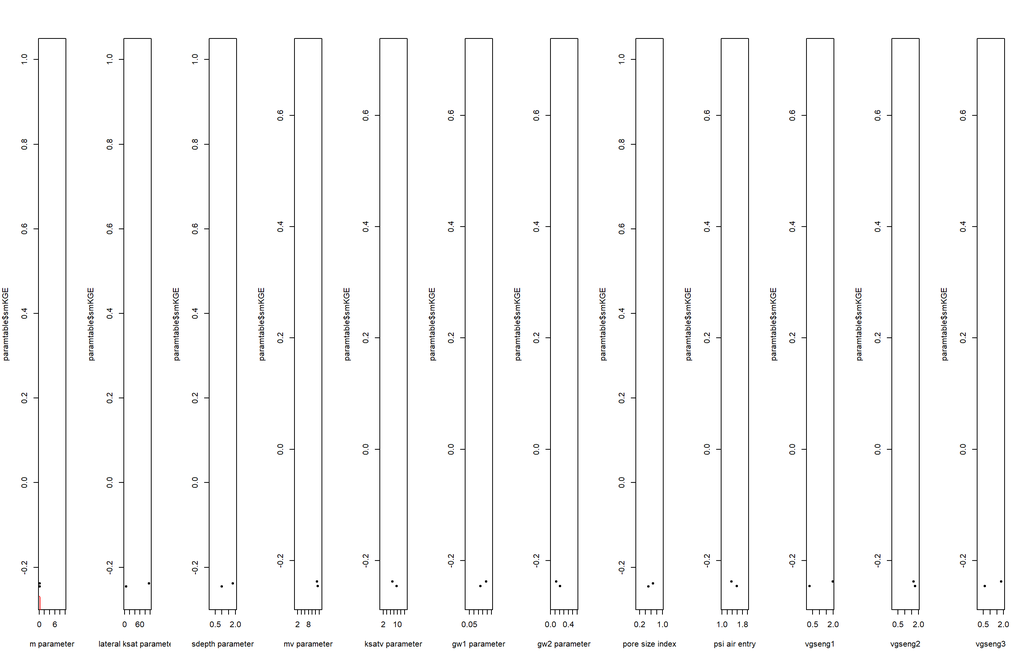

```r
par(old.par)

old.par <- par(mfrow=c(1, 12), mar = c(5,4,4,2))

{plot(paramtable$m,paramtable$smKGE,ylim = c(-0.25,1),xlab = "m parameter", pch = 20)
lines(lowess(paramtable$m,paramtable$smKGE, f = 0.1),col="red")
plot(paramtable$k,paramtable$smKGE,ylim = c(-0.25,1),xlab = "lateral ksat parameter", pch = 20)
lines(lowess(paramtable$k,paramtable$smKGE, f = 0.1),col="red")
plot(paramtable$soil_dep,paramtable$smKGE,ylim = c(-0.25,1),xlab = "sdepth parameter", pch = 20)
lines(lowess(paramtable$soil_dep,paramtable$smKGE, f = 0.1),col="red")
plot(paramtable$m_v,paramtable$smKGE,ylim = c(-0.25,0.7),xlab = "mv parameter", pch = 20)
lines(lowess(paramtable$m_v,paramtable$smKGE, f = 0.1),col="red")
plot(paramtable$k_v,paramtable$smKGE,ylim = c(-0.25,0.7),xlab = "ksatv parameter", pch = 20)
lines(lowess(paramtable$k_v,paramtable$smKGE, f = 0.1),col="red")
plot(paramtable$gw1,paramtable$smKGE,ylim = c(-0.25,0.7),xlab = "gw1 parameter", pch = 20)
lines(lowess(paramtable$gw1,paramtable$smKGE, f = 0.1),col="red")
plot(paramtable$gw2,paramtable$smKGE,ylim = c(-0.25,0.7),xlab = "gw2 parameter", pch = 20)
lines(lowess(paramtable$gw2,paramtable$smKGE, f = 0.1),col="red")}

{plot(paramtable$pa,paramtable$smKGE,ylim = c(-0.25,1),xlab = "pore size index", pch = 20)
lines(lowess(paramtable$pa,paramtable$smKGE, f = 0.1),col="red")
plot(paramtable$po,paramtable$smKGE,ylim = c(-0.25,0.7),xlab = "psi air entry", pch = 20)
lines(lowess(paramtable$po,paramtable$smKGE, f = 0.1),col="red")
plot(paramtable$vgseng1,paramtable$smKGE,ylim = c(-0.25,0.7),xlab = "vgseng1", pch = 20)
lines(lowess(paramtable$vgseng1,paramtable$smKGE, f = 0.1),col="red")
plot(paramtable$vgseng2,paramtable$smKGE,ylim = c(-0.25,0.7),xlab = "vgseng2", pch = 20)
lines(lowess(paramtable$vgseng2,paramtable$smKGE, f = 0.1),col="red")
plot(paramtable$vgseng3,paramtable$smKGE,ylim = c(-0.25,0.7),xlab = "vgseng3", pch = 20)
lines(lowess(paramtable$vgseng3,paramtable$smKGE, f = 0.1),col="red")}
```

```r
par(old.par)

### end plot all data for GLUE

paste0("cwws32_dsm_run",which(NSElist == Reduce(max, NSElist), arr.ind=TRUE),"$streamflow")
```

```
## [1] "cwws32_dsm_run85$streamflow"
```

```r
paste0("cwws32_dsm_run",which(lnNSElist == Reduce(max, lnNSElist), arr.ind=TRUE),"$streamflow")
```

```
## [1] "cwws32_dsm_run19$streamflow"
```

```r
paste0("cwws32_dsm_run",which(KGElist == Reduce(max, KGElist), arr.ind=TRUE),"$streamflow")
```

```
## [1] "cwws32_dsm_run20$streamflow"
```

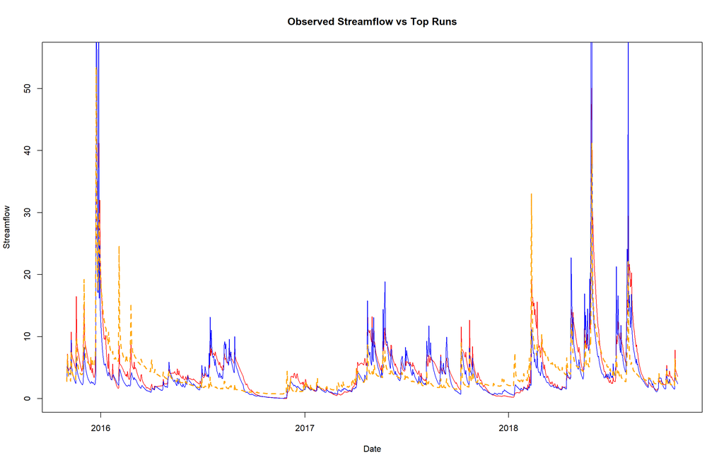

```r
{plot(cwws32_dsm_run3$date,cwws32_dsm_run3$streamflow, type = "l", col = 'red', main = "Observed Streamflow vs Top Runs", xlab = "Date", ylab = "Streamflow")
lines(cwws32_dsm_run5$date,cwws32_dsm_run5$streamflow, col = 'blue')
#lines(cwws32_dsm_run46$bd$date,cwws32_dsm_run46$bd$streamflow, col = 'green')
lines(simmerge1$Date,simmerge1$observedstreamflow, col = 'orange', lwd = 2, lty = 2)}
```

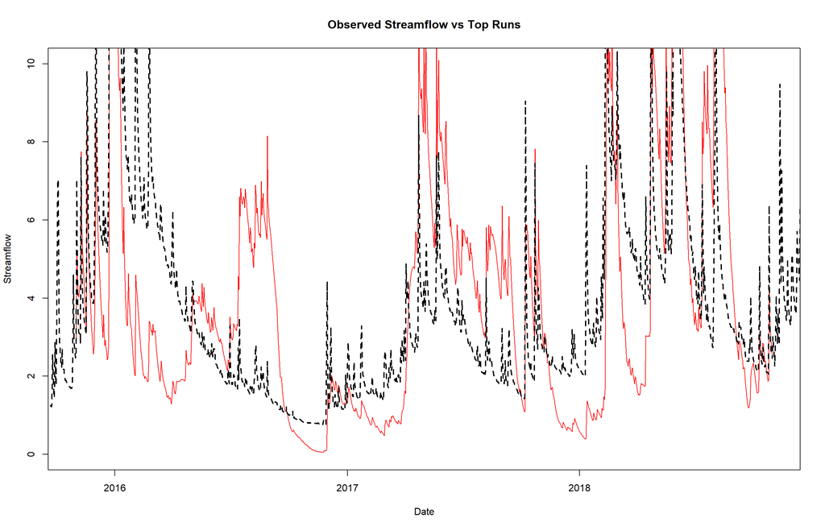

```r
#{plot(paste("cwws32_run",which(NSElist == Reduce(max, NSElist), arr.ind=TRUE),"$bd$date", sep = ""),paste("cwws32_run",which(NSElist == Reduce(max, NSElist), arr.ind=TRUE),"$bd$streamflow", sep = ""), type = "l", col = 'red', main = "Observed Streamflow vs Top Runs", xlab = "Date", ylab = "Streamflow")
#lines(paste("cwws32_run",which(lnNSElist == Reduce(max, lnNSElist), arr.ind=TRUE),"$bd$date", sep = ""),paste("cwws32_run",which(lnNSElist == Reduce(max, lnNSElist), arr.ind=TRUE),"$bd$streamflow", sep = ""), col = 'blue')
#lines(cwws32_run80$bd$date,cwws32_run80$bd$streamflow, col = 'green')
#lines(paste("cwws32_run",which(KGElist == Reduce(max, KGElist), arr.ind=TRUE),"$bd$date", sep = ""),paste("cwws32_run",which(KGElist == Reduce(max, KGElist), arr.ind=TRUE),"$bd$streamflow", sep = ""), col = 'orange', lwd = 2, lty = 2)
#legend("topleft",inset = 0.05, legend=c("Oberved Discharge","Best NSE","BEST lnNSE","Best KGE"), col=c("orange","red","blue","green"), lty=c(2,1,1,1))}

{plot(cwws32_dsm_run16$date,cwws32_dsm_run16$streamflow, type = "l", col = 'red', main = "Observed Streamflow vs Top Runs", xlab = "Date", ylab = "Streamflow", ylim = c(0,10))
#lines(cwws32_dsm_run47$bd$date,cwws32_dsm_run47$bd$streamflow, col = 'blue')
lines(obsws32$Date,obsws32$discharge_mm, col = 'black', lwd = 2, lty = 2)}
```

```r
which(NSElist == Reduce(max, NSElist), arr.ind=TRUE)
```

```
## [1] 85
```

```r
which(lnNSElist == Reduce(max, lnNSElist), arr.ind=TRUE)
```

```
## [1] 19
```

```r
which(KGElist == Reduce(max, KGElist), arr.ind=TRUE)
```

```
## [1] 20
```

```r
which(smNSElist == Reduce(max, smNSElist), arr.ind=TRUE)
```

```
## [1] 23
```

```r
which(smlnNSElist == Reduce(max, smlnNSElist), arr.ind=TRUE)
```

```
## [1] 23
```

```r
which(smKGElist == Reduce(max, smKGElist), arr.ind=TRUE)
```

```
## [1] 38
```

```r
paramtable[which(NSElist == Reduce(max, NSElist), arr.ind=TRUE),]
```

```
##           m        k  soil_dep       m_v      k_v       gw1       gw2        pa
## 85 5.370098 52.72373 0.1573705 0.7459684 10.35425 0.0343746 0.3241657 0.7564442
##          po  vgseng1 vgseng2 vgseng3 run rowname      NSE       lnNSE      KGE
## 85 1.812101 1.490146 1.33589 1.96583  85    6159 0.546636 0.002605299 0.688931
##        smNSE smlnNSE     smKGE    calNSE  callnNSE     calKGE  calsmNSE
## 85 -28.39931 -133.67 -0.394291 -2.668913 -1.587072 -0.2236845 -28.39931
##    calsmlnNSE  calsmKGE    valNSE   vallnNSE    valKGE  valsmNSE valsmlnNSE
## 85    -133.67 -0.394291 0.5636223 -0.8995175 0.7722999 -73.88325  -436.2104
##      valsmKGE
## 85 -0.2600383
```

```r
paramtable[which(lnNSElist == Reduce(max, lnNSElist), arr.ind=TRUE),]
```

```
##           m        k soil_dep      m_v      k_v       gw1       gw2        pa
## 19 1.410735 30.83061 1.382676 5.852734 3.726986 0.2816848 0.2575848 0.2916331
##          po  vgseng1  vgseng2  vgseng3 run rowname       NSE     lnNSE
## 19 1.859008 1.279521 1.123132 1.754444  19    5615 0.4996539 0.3525943
##          KGE     smNSE   smlnNSE      smKGE    calNSE  callnNSE      calKGE
## 19 0.6398364 -31.20898 -187.9668 -0.4506767 -2.575776 -1.280038 -0.03421028
##     calsmNSE calsmlnNSE   calsmKGE    valNSE  vallnNSE   valKGE  valsmNSE
## 19 -31.20898  -187.9668 -0.4506767 0.4690259 0.4680898 0.736667 -80.75876
##    valsmlnNSE   valsmKGE
## 19  -608.9252 -0.3457051
```

```r
paramtable[which(KGElist == Reduce(max, KGElist), arr.ind=TRUE),]
```

```
##           m        k soil_dep      m_v      k_v       gw1       gw2        pa
## 20 3.192353 3.802293 1.727122 5.974606 3.861233 0.2601113 0.4437058 0.5579785
##          po  vgseng1  vgseng2   vgseng3 run rowname       NSE       lnNSE
## 20 1.521729 1.832505 1.102582 0.5133313  20    1081 0.4295115 -0.01595754
##          KGE     smNSE   smlnNSE      smKGE    calNSE  callnNSE     calKGE
## 20 0.7114428 -26.78257 -111.9023 -0.4424092 -1.928365 -1.403355 -0.1755041
##     calsmNSE calsmlnNSE   calsmKGE    valNSE  vallnNSE    valKGE  valsmNSE
## 20 -26.78257  -111.9023 -0.4424092 0.1580974 -1.077758 0.5339306 -70.41611
##    valsmlnNSE   valsmKGE
## 20  -374.5928 -0.2325737
```

```r
paramtable[which(smNSElist == Reduce(max, smNSElist), arr.ind=TRUE),]
```

```
##           m        k  soil_dep      m_v      k_v       gw1       gw2        pa
## 23 7.658168 61.17758 0.7090951 10.12554 1.224369 0.2195068 0.5063794 0.7620216
##          po  vgseng1  vgseng2   vgseng3 run rowname       NSE      lnNSE
## 23 1.048394 1.241617 1.297863 0.2541754  23    1929 0.2017489 -0.7689393
##          KGE     smNSE  smlnNSE      smKGE    calNSE  callnNSE     calKGE
## 23 0.6225045 -19.03076 -51.0699 -0.3203001 -2.282677 -2.495077 -0.3471377
##     calsmNSE calsmlnNSE   calsmKGE     valNSE  vallnNSE    valKGE  valsmNSE
## 23 -19.03076   -51.0699 -0.3203001 -0.2040652 -2.985596 0.4338508 -52.21593
##    valsmlnNSE    valsmKGE
## 23  -181.3391 -0.02213455
```

```r
paramtable[which(smlnNSElist == Reduce(max, smlnNSElist), arr.ind=TRUE),]
```

```
##           m        k  soil_dep      m_v      k_v       gw1       gw2        pa
## 23 7.658168 61.17758 0.7090951 10.12554 1.224369 0.2195068 0.5063794 0.7620216
##          po  vgseng1  vgseng2   vgseng3 run rowname       NSE      lnNSE
## 23 1.048394 1.241617 1.297863 0.2541754  23    1929 0.2017489 -0.7689393
##          KGE     smNSE  smlnNSE      smKGE    calNSE  callnNSE     calKGE
## 23 0.6225045 -19.03076 -51.0699 -0.3203001 -2.282677 -2.495077 -0.3471377
##     calsmNSE calsmlnNSE   calsmKGE     valNSE  vallnNSE    valKGE  valsmNSE
## 23 -19.03076   -51.0699 -0.3203001 -0.2040652 -2.985596 0.4338508 -52.21593
##    valsmlnNSE    valsmKGE
## 23  -181.3391 -0.02213455
```

```r
paramtable[which(smKGElist == Reduce(max, smKGElist), arr.ind=TRUE),]
```

```
##            m        k soil_dep      m_v     k_v      gw1       gw2        pa
## 38 0.1359431 94.70758 1.798364 12.68998 7.17253 0.236533 0.1239401 0.6715787
##          po  vgseng1  vgseng2  vgseng3 run rowname        NSE      lnNSE
## 38 1.367797 1.963257 1.651261 1.816664  38    1187 -0.4625206 -0.2198138
##          KGE    smNSE   smlnNSE      smKGE    calNSE  callnNSE     calKGE
## 38 0.3719346 -26.9777 -122.5856 -0.2378356 -3.184233 -1.322405 -0.5018463
##    calsmNSE calsmlnNSE   calsmKGE     valNSE  vallnNSE      valKGE  valsmNSE
## 38 -26.9777  -122.5856 -0.2378356 -0.8905492 -3.811536 -0.07991287 -66.73276
##    valsmlnNSE   valsmKGE
## 38  -323.0688 -0.1757858
```